# Comprehensive Knowledge of C++(V18.05)

autor:ichiroprogrammer

# 用語解説

この章では、このドキュメントで使用する用語の解説をする。

**この章の構成**

型とインスタンス  
算術型  
汎整数型  
整数型  
算術変換  
汎整数拡張  
POD  
標準レイアウト型  
トリビアル型  
underlying type  
不完全型  
完全型  
ポリモーフィックなクラス  
インターフェースクラス  
constインスタンス  
constexprインスタンスと関数  
ユーザ定義リテラル演算子  
std::string型リテラル

オブジェクトと生成  
特殊メンバ関数  
初期化子リストコンストラクタ  
継承コンストラクタ  
委譲コンストラクタ  
非explitなコンストラクタによる暗黙の型変換  
NSDMI  
一様初期化  
AAAスタイル  
オブジェクトの所有権  
オブジェクトのライフタイム  
クラスのレイアウト

オブジェクトのコピー  
シャローコピー  
ディープコピー  
スライシング

name lookupと名前空間  
ルックアップ  
name lookup  
two phase name lookup  
実引数依存探索  
ADL  
関連名前空間  
SFINAE  
name-hiding  
ドミナンス  
ダイヤモンド継承  
仮想継承  
仮想基底  
using宣言  
usingディレクティブ

expressionと値カテゴリ  
expression  
lvalue  
rvalue  
rvalue修飾  
lvalue修飾  
リファレンス修飾  
decltype

リファレンス  
ユニバーサルリファレンス  
forwardingリファレンス  
perfect forwarding  
リファレンスcollapsing  
danglingリファレンス  
danglingポインタ

エクセプション安全性の保証  
no-fail保証  
強い保証  
基本保証

シンタックス、セマンティクス  
等価性のセマンティクス  
copyセマンティクス  
moveセマンティクス

C++コンパイラ  
g++  
clang++

C++その他  
オーバーライドとオーバーロードの違い  
実引数/仮引数  
範囲for文  
ラムダ式  
ジェネリックラムダ  
関数tryブロック  
単純代入  
ill-formed  
well-formed  
one-definition rule  
ODR  
RVO(Return Value Optimization)  
SSO(Small String Optimization)  
Most Vexing Parse  
RTTI  
Run-time Type Information  
simple-declaration  
typeid  
トライグラフ  
フリースタンディング環境

ソフトウェア一般  
凝集度  
サイクロマティック複雑度  
Spurious Wakeup  
副作用  
is-a  
has-a  
is-implemented-in-terms-of

非ソフトウェア用語  
割れ窓理論  
車輪の再発明

## 型とインスタンス

### 算術型

算術型とは下記の型の総称である。

- 汎整数型(bool, char, int, unsigned int, long long等)
- 浮動小数点型(float、double、long double)

算術型のサイズは下記のように規定されている。

- 1 == sizeof(bool) == sizeof(char)
- sizeof(char) <= sizeof(short) <= sizeof(int) <= sizeof(long) <= sizeof(long long)
- 4 <= sizeof(long)
- 8 <= sizeof(long long)
- 4 == sizeof(float)
- 8 == sizeof(double) <= sizeof(long double)

### 汎整数型

汎整数型とは下記の型の総称である。

- 論理型(bool)
- 文字型(char、wchar_t等)
- 整数型(int、unsigned int、long等)

### 整数型

整数型とは下記の型の総称である。

- char
- signed char
- unsigned char
- short
- unsigned short
- int
- unsigned int
- long
- unsigned long
- long long
- unsigned long long

### 算術変換

C++における算術変換とは、算術演算の1つのオペランドが他のオペランドと同じ型でない場合、 1つのオペランドを他のオペランドと同じ型に変換するプロセスのことを指す。

算術変換は、汎整数拡張と通常算術変換に分けられる。

```cpp
    // @@@ example/term_explanation/integral_promotion_ut.cpp 11

    bool           bval{};
    char           cval{};
    short          sval{};
    unsigned short usval{};
    int            ival{};
    unsigned int   uival{};
    long           lval{};
    unsigned long  ulval{};
    float          fval{};
    double         dval{};

    auto ret_0 = 3.14159 + 'a';  // 'a'は汎整数拡張でintになった後、さらに通常算術変換でdoubleに
    static_assert(std::is_same<decltype(ret_0), double>::value, "");

    auto ret_1 = dval + ival;  // ivalは通常算術変換でdoubleに
    static_assert(std::is_same<decltype(ret_1), double>::value, "");

    auto ret_2 = dval + fval;  // fvalは通常算術変換でdoubleに
    static_assert(std::is_same<decltype(ret_2), double>::value, "");

    auto ret_3 = ival = dval;  // dvalは通常算術変換でintに
    static_assert(std::is_same<decltype(ret_3), int>::value, "");

    bval = dval;  // dvalは通常算術変換でboolに
    ASSERT_FALSE(bval);

    auto ret_4 = cval + fval;  // cvalは汎整数拡張でintになった後、さらに通常算術変換でfloatに
    static_assert(std::is_same<decltype(ret_4), float>::value, "");

    auto ret_5 = sval + cval;  // svalとcvalは汎整数拡張でintに
    static_assert(std::is_same<decltype(ret_5), int>::value, "");

    auto ret_6 = cval + lval;  // cvalはは汎整数拡張でintになった後、通常算術変換でlongに
    static_assert(std::is_same<decltype(ret_6), long>::value, "");

    auto ret_7 = ival + ulval;  // ivalは通常算術変換でunsigned longに
    static_assert(std::is_same<decltype(ret_7), unsigned long>::value, "");

    auto ret_8 = usval + ival;  // usvalは汎整数拡張でintに
                                // ただし、この変換はunsigned shortとintのサイズに依存する
    static_assert(std::is_same<decltype(ret_8), int>::value, "");

    auto ret_9 = uival + lval;  // uivalは通常算術変換でlongに
                                // ただし、この変換はunsigned intとlongのサイズに依存する
    static_assert(std::is_same<decltype(ret_9), long>::value, "");
```

一様初期を使用することで、 変数定義時の算術変換による意図しない値の変換(縮小型変換)を防ぐことができる。

```cpp
    // @@@ example/term_explanation/integral_promotion_ut.cpp 62

    int i{-1};
    // int8_t i8 {i};  縮小型変換によりコンパイル不可
    int8_t i8 = i;  // intからint8_tへの型変換
    // これには問題ないが

    ASSERT_EQ(-1, i8);

    // uint8_t ui8 {i};  縮小型変換によりコンパイル不可
    uint8_t ui8 = i;  // intからuint8_tへの型変換
    // おそらく意図通りではない

    ASSERT_EQ(255, ui8);
```

以下に示すように、算術変換の結果は直感に反することがあるため、注意が必要である。

```cpp
    // @@@ example/term_explanation/integral_promotion_ut.cpp 81

    int          i{-1};
    unsigned int ui{1};

    // ASSERT_TRUE(i < ui);
    ASSERT_TRUE(i > ui);  // 算術変換の影響で、-1 < 1が成立しない

    signed short   s{-1};
    unsigned short us{1};

    ASSERT_TRUE(s < us);  // 汎整数拡張により、-1 < 1が成立
```

### 汎整数拡張

bool、char、signed char、unsigned char、short、unsigned short型の変数が、 算術のオペランドとして使用される場合、

- その変数の型の取り得る値全てがintで表現できるのならば、int型に変換される。
- そうでなければ、その変数はunsigned int型に変換される。

この変換を汎整数拡張と呼ぶ。

従って、sizof(short) < sizeof(int)である処理系では、 bool、char、signed char、unsigned char、short、unsigned short型の変数は、 下記のようにintに変換される。

```cpp
    // @@@ example/term_explanation/integral_promotion_ut.cpp 100

    bool bval;
    static_assert(std::is_same<int, decltype(bval + bval)>::value, "");

    char cval;
    static_assert(std::is_same<int, decltype(cval + cval)>::value, "");

    unsigned char ucval = 128;
    static_assert(std::is_same<int, decltype(ucval + ucval)>::value, "");
    ASSERT_EQ(256, ucval + ucval);  // 汎整数拡張により256になる

    static_assert(std::is_same<int, decltype(cval + ucval)>::value, "");

    short sval;
    static_assert(std::is_same<int, decltype(sval + sval)>::value, "");

    unsigned short usval;
    static_assert(std::is_same<int, decltype(usval + usval)>::value, "");

    static_assert(std::is_same<int, decltype(sval + usval)>::value, "");
```

### POD

PODとは、 Plain Old Dataの略語であり、

```cpp
    std::is_pod<T>::value
```

がtrueとなる型Tを指す。下記のコードはその使用例である。

```cpp
    // @@@ example/term_explanation/pod_ut.cpp 7

    static_assert(std::is_pod<int>::value, "");
    static_assert(std::is_pod<int const>::value, "");
    static_assert(std::is_pod<int*>::value, "");
    static_assert(std::is_pod<int[3]>::value, "");
    static_assert(!std::is_pod<int&>::value, "");  // リファレンスはPODではない

    struct Pod {};

    static_assert(std::is_pod<Pod>::value, "");
    static_assert(std::is_pod<Pod const>::value, "");
    static_assert(std::is_pod<Pod*>::value, "");
    static_assert(std::is_pod<Pod[3]>::value, "");
    static_assert(!std::is_pod<Pod&>::value, "");

    struct NonPod {  // コンストラクタがあるためPODではない
        NonPod();
    };

    static_assert(!std::is_pod<NonPod>::value, "");
```

概ね、C言語と互換性のある型を指すと思って良い。

「型がトリビアル型且つ標準レイアウト型であること」と 「型がPODであること」は等価であるため、C++20では、 [PODという用語は非推奨](https://cpprefjp.github.io/lang/cpp20/deprecate_pod.html)となった。

### 標準レイアウト型

標準レイアウト型とは、

```cpp
    std::is_standard_layout<T>::value
```

がtrueとなる型Tを指す。下記のコードはその使用例である。

```cpp
    // @@@ example/term_explanation/pod_ut.cpp 31

    static_assert(std::is_standard_layout<int>::value, "");
    static_assert(std::is_standard_layout<int*>::value, "");
    static_assert(std::is_standard_layout<int[1]>::value, "");
    static_assert(!std::is_standard_layout<int&>::value, "");

    enum class SizeUndefined { su_0, su_1 };

    struct StanderdLayout {  // 標準レイアウトだがトリビアルではない
        StanderdLayout() : a{0}, b{SizeUndefined::su_0} {}
        int           a;
        SizeUndefined b;
    };

    static_assert(std::is_standard_layout<StanderdLayout>::value, "");
    static_assert(!std::is_trivial<StanderdLayout>::value, "");
    static_assert(!std::is_pod<StanderdLayout>::value, "");
```

型がPODである場合、その型は標準レイアウト型である。

### トリビアル型

トリビアル型とは、

```cpp
    std::is_trivial<T>::value
```

がtrueとなる型Tを指す。下記のコードはその使用例である。

```cpp
    // @@@ example/term_explanation/pod_ut.cpp 52

    static_assert(std::is_trivial<int>::value, "");
    static_assert(std::is_trivial<int*>::value, "");
    static_assert(std::is_trivial<int[1]>::value, "");
    static_assert(!std::is_trivial<int&>::value, "");

    enum class SizeUndefined { su_0, su_1 };

    struct Trivial {      // トリビアルだが標準レイアウトではない
        int&          a;  // リファレンスは標準レイアウトではない
        SizeUndefined b;
    };

    static_assert(!std::is_standard_layout<Trivial>::value, "");
    static_assert(std::is_trivial<Trivial>::value, "");
    static_assert(!std::is_pod<Trivial>::value, "");
```

型がPODである場合、その型はトリビアル型である。

### underlying type

underlying typeとは、enumやenum classの汎整数表現を指定できるようにするために、 C++11で導入されたシンタックスである。

```cpp
    // @@@ example/term_explanation/underlying_type_ut.cpp 9

    // 従来のenum
    enum NormalEnum {
        ...
    };

    // enum underlying typeがint8_tに指定された従来のenum
    enum NormalEnumWithUnderlyingType : int8_t {
        ...
    };

    // enum class
    enum class EnumClass {
        ...
    };

    // enum underlying typeがint64_tに指定されたenum class
    enum class EnumClassWithUnderlyingType : int64_t {
        ...
    };
```

```cpp
    // @@@ example/term_explanation/underlying_type_ut.cpp 38

    ASSERT_EQ(4, sizeof(NormalEnum));  // 列挙子の値を表現するのに十分なサイズの整数型で処理系依存

    // NormalEnumWithUnderlyingTypeのunderlying typeはint8_t
    static_assert(std::is_same_v<int8_t, std::underlying_type_t<NormalEnumWithUnderlyingType>>);
    ASSERT_EQ(sizeof(int8_t), sizeof(NormalEnumWithUnderlyingType));

    ASSERT_EQ(4, sizeof(EnumClass));  // 列挙子の値を表現するのに十分なサイズの整数型で処理系依存

    // EnumClassWithUnderlyingTypeのunderlying typeはint64_t
    static_assert(std::is_same_v<int64_t, std::underlying_type_t<EnumClassWithUnderlyingType>>);
    ASSERT_EQ(sizeof(int64_t), sizeof(EnumClassWithUnderlyingType));
```

### 不完全型

不完全型とは、型のサイズや構造が不明な型を指す。 下記のような場合、不完全型となる。

```cpp
    // @@@ example/term_explanation/incomplete_type_ut.cpp 6

    class A;  // Aの前方宣言
              // これ以降、Aは不完全型となる

    // auto a = sizeof(A);  Aが不完全型であるため、コンパイルエラー

    class A {  // この宣言により、この行以降はAは完全型になる
    public:
        // 何らかの宣言
    };

    auto a = sizeof(A);  // Aが完全型であるため、コンパイル可能
```

### 完全型

不完全型ではない型を指す。

### ポリモーフィックなクラス

ポリモーフィックなクラスとは、仮想関数を持つクラスを指す。 なお、純粋仮想関数を持つクラスは、仮想クラスと呼ばれれる。

### インターフェースクラス

インターフェースクラスとは、純粋仮想関数のみを持つ抽象クラスのことを指す。 インターフェースクラスは、クラスの実装を提供することなく、 クラスのインターフェースを定義するために使用される。 インターフェースクラスは、クラスの仕様を定義するために使用されるため、 多くの場合、抽象基底クラスとして使用される。

```cpp
    // @@@ example/term_explanation/interface_class.cpp 8

    class InterfaceClass {  // インターフェースクラス
    public:
        virtual void DoSomething(int32_t) = 0;
        virtual bool IsXxx() const        = 0;
        virtual ~InterfaceClass()         = 0;
    };

    class NotInterfaceClass {  // メンバ変数があるためインターフェースクラスではない
    public:
        NotInterfaceClass();
        virtual void DoSomething(int32_t) = 0;
        virtual bool IsXxx() const        = 0;
        virtual ~NotInterfaceClass()      = 0;

    private:
        int32_t num_;
    };
```

### constインスタンス

constインスタンスとはランタイムの初期化時に値が確定し、その後、状態が不変であるインスタンスである。

### constexprインスタンスと関数

constexprインスタンスとはコンパイル時に値が確定するインスタンスである。 当然、ランタイム時でも不変である。

```cpp
    // @@@ example/term_explanation/constexpr_ut.cpp 6

    constexpr double PI{3.14159265358979323846};  // PIはconstexpr
```

constexprとして宣言された関数の戻り値がコンパイル時に確定する場合、 その関数の呼び出し式はconstexprと扱われる。 従って、この値はテンプレートパラメータやstatic_assertのオペランドに使用することができる。

```cpp
    // @@@ example/term_explanation/constexpr_ut.cpp 10

    constexpr int f(int a) noexcept { return a * 3; }  // aがconstexprならばf(a)もconstexpr

    int g(int a) noexcept { return a * 3; }  // aがconstexprであってもg(a)は非constexpr

    template <int N>
    struct Templ {
        static constexpr auto value = N;
    };
```

```cpp
    // @@@ example/term_explanation/constexpr_ut.cpp 25

    auto x = int{0};

    constexpr auto a = f(3);  // f(3)はconstexprなのでaの初期化が可能
    // constexpr auto b = f(x);  // xは非constexprなのでbの初期化はコンパイルエラー
    auto const c = f(3);  // cはconstexprとすべき
    // constexpr auto d = g(3);  // g(3)は非constexprなのでdの初期化はコンパイルエラー
    auto const e = g(x);  // eはここで初期化して、この後不変

    constexpr auto pi = PI;  // PIもconstexprなので初期化が可能

    auto templ_a = Templ<a>{};     // aはconstexprなのでaの初期化が可能
    auto templ_f = Templ<f(a)>{};  // f(a)はconstexprなのでaの初期化が可能
    // auto templ_x = Templ<x>{};  // xは非constexprなのでテンプレートパラメータに指定できない

    static_assert(templ_a.value == 9);
    // static_assert(x == 0);  // xは非constexprなのでstatic_assertで使用できない
```

下記のようなリカーシブな関数でも場合によってはconstexprにできる。 これによりこの関数の実行速度は劇的に向上する。

```cpp
    // @@@ example/term_explanation/constexpr_ut.cpp 48

    inline constexpr uint32_t BitMask(uint32_t bit_len) noexcept
    {
        if (bit_len == 0) {
            return 0x0;
        }

        return BitMask(bit_len - 1) | (0x01 << (bit_len - 1));
    }
```

下記の単体テストが示すように、

- 引数がconstexprである場合、上記constexpr関数の戻り値はconstexprになるため、 static_assertのオペランド式としても利用できる。
- 引数がconstexprでない場合、上記constexpr関数は通常の関数として振舞うため、 戻り値はconstexprとならない。

```cpp
    // @@@ example/term_explanation/constexpr_ut.cpp 63

    constexpr auto b_0x00000000 = BitMask(0);
    constexpr auto b_0x000000ff = BitMask(8);

    static_assert(b_0x00000000 == 0x00000000);
    static_assert(b_0x000000ff == 0x000000ff);
    static_assert(BitMask(16) == 0x0000'ffff);

    constexpr auto bit_len_constexpr = 24U;
    static_assert(BitMask(bit_len_constexpr) == 0x00ff'ffff);

    auto bit_len = 24U;

    // bit_lenがconstexprでないことによりBitMask(bit_len)もconstexprでないため、
    // コンパイルできない
    // constexpr auto b_0x00ffffff = BitMask(bit_len);

    // b_0x00ffffffの定義からconstexprを外せばコンパイル可能
    // ただし、コンパイル時でなくランタイム時動作になるため動作が遅い
    auto b_0x00ffffff = BitMask(bit_len);

    ASSERT_EQ(b_0x00ffffff, 0x00ff'ffff);
```

下記のようにクラスのコンストラクタをconstexprとすることで、 コンパイル時にリテラルとして振る舞うクラスを定義することができる。

```cpp
    // @@@ example/term_explanation/constexpr_ut.cpp 90

    class Integer {
    public:
        constexpr Integer(int32_t integer) noexcept : integer_{integer} {}
        constexpr int32_t Get() const noexcept { return integer_; }  // constexprメンバ関数はconst
        constexpr int32_t Allways2() const noexcept { return 2; }    // constexprメンバ関数はconst
        static constexpr int32_t Allways3() noexcept { return 3; }   // static関数のconstexpr化

    private:
        int32_t integer_;
    };
```

```cpp
    // @@@ example/term_explanation/constexpr_ut.cpp 107

    constexpr auto int3     = 3;                         // int3はconstexpr
    constexpr auto integer3 = Integer{int3};             // integer3自体がconstexpr
    static_assert(integer3.Get() == 3, "wrong number");  // integer3.Get()もconstexpr

    auto integer4 = Integer{4};
    // integer4は非constexprであるため、integer4.Get()も非constexprとなり、コンパイル不可
    // static_assert(integer4.Get() == 4, "wrong number");

    // integer4は非constexprだが、integer4.Allway2()はconstexprであるため、コンパイル可能
    static_assert(integer4.Allways2() == 2, "wrong number");
```

### ユーザ定義リテラル演算子

ユーザ定義リテラル演算子とは以下のようなものである。

```cpp
    // @@@ example/term_explanation/user_defined_literal_ut.cpp 4

    constexpr int32_t one_km = 1000;

    // ユーザ定義リテラル演算子の定義
    constexpr int32_t operator""_kilo_meter(unsigned long long num_by_mk) { return num_by_mk * one_km; }
    constexpr int32_t operator""_meter(unsigned long long num_by_m) { return num_by_m; }
```

```cpp
    // @@@ example/term_explanation/user_defined_literal_ut.cpp 15

    int32_t km = 3_kilo_meter;  // ユーザ定義リテラル演算子の利用
    int32_t m  = 3000_meter;    // ユーザ定義リテラル演算子の利用

    ASSERT_EQ(m, km);
```

### std::string型リテラル

“xxx”sとすることで、std::string型のリテラルを作ることができる。

```cpp
    // @@@ example/term_explanation/user_defined_literal_ut.cpp 26

    using namespace std::literals::string_literals;

    auto a = "str"s;  // aはstd::string
    auto b = "str";   // bはconst char*

    static_assert(std::is_same_v<decltype(a), std::string>);
    ASSERT_EQ(std::string{"str"}, a);

    static_assert(std::is_same_v<decltype(b), char const*>);
    ASSERT_STREQ("str", b);
```

## オブジェクトと生成

### 特殊メンバ関数

特殊メンバ関数とは下記の関数を指す。

- デフォルトコンストラクタ
- copyコンストラクタ
- copy代入演算子
- moveコンストラクタ
- move代入演算子
- デストラクタ

ユーザがこれらを一切定義しない場合、または一部のみを定義する場合、 コンパイラは、下記のテーブル等で示すルールに従い、特殊関数メンバの宣言、定義の状態をを定める。

左1列目がユーザによる各関数の宣言を表し、2列目以降はユーザ宣言の影響による各関数の宣言の状態を表す。  
下記表において、

- 「= default」とは、「コンパイラによってその関数が= defaultと宣言された」状態であることを表す。
- 「= default」とは、= defaultと同じであるが、バグが発生しやすいので推奨されない。
- 「宣言無し」とは、「コンパイラによってその関数が= defaultと宣言された状態ではない」ことを表す。
  - 「moveコンストラクタが= defaultと宣言された状態ではない」且つ 「copyコンストラクタが宣言されている」場合、 rvalueを使用したオブジェクトの初期化には、 moveコンストラクタの代わりにcopyコンストラクタが使われる。
  - 「move代入演算子が= defaultと宣言された状態ではない」且つ 「copy代入演算子が宣言されている」場合、 rvalueを使用したオブジェクトの代入には、 move代入演算子の代わりにcopy代入演算子が使われる。
- 「= delete」とは「コンパイラによってその関数が= deleteと宣言された」状態であることを表す。

| ユーザによる特殊関数の宣言 | デフォルト コンストラクタ | デストラクタ | copy コンストラクタ | copy 代入演算子 | move コンストラクタ | move 代入演算子 |
| --- | --- | --- | --- | --- | --- | --- |
| 宣言無し | = default | = default | = default | = default | = default | = default |
| 非デフォルトコンストラクタ | 宣言なし | = default | = default | = default | = default | = default |
| デフォルトコンストラクタ | - | = default | = default | = default | = default | = default |
| デストラクタ | = default | - | = default | = default | 宣言なし | 宣言なし |
| copyコンストラクタ | 宣言なし | = default | - | = default | 宣言なし | 宣言なし |
| copy代入演算子 | = default | = default | = default | - | 宣言なし | 宣言なし |
| moveコンストラクタ | 宣言なし | = default | = delete | = delete | - | 宣言なし |
| move代入演算子 | = default | = default | = delete | = delete | 宣言なし | - |

上記表より、下記のようなことがわかる。

- ユーザが上記6メンバ関数を一切宣言しない場合、それらはコンパイラにより暗黙に宣言、定義される。
- ユーザがcopyコンストラクタを宣言した場合、デフォルトコンストラクタは暗黙に宣言、定義されない。
- ユーザがcopyコンストラクタを宣言した場合、copy代入演算子はコンパイラにより暗黙に宣言、 定義されるが、そのことは推奨されない(= defaultは非推奨のdefault宣言を指す)。
- moveコンストラクタ、move代入演算子は、 以下のいずれもが明示的に宣言されていない場合にのみ暗黙に宣言、定義される。
  - copyコンストラクタ
  - copy代入演算子(operator =)
  - moveコンストラクタ
  - move代入演算子
  - デストラクタ
- ユーザがmoveコンストラクタまたはmove代入演算子を宣言した場合、 copyコンストラクタ、copy代入演算子は= deleteされる。

### 初期化子リストコンストラクタ

初期化子リストコンストラクタ(リスト初期化用のコンストラクタ)とは、 {}によるリスト初期化をサポートするためのコンストラクタである。 下記コードでは、 E::E(std::initializer_list<uint32_t>)が初期化子リストコンストラクタである。

```cpp
    // @@@ example/term_explanation/constructor_ut.cpp 6

    class E {
    public:
        E() : str_{"default constructor"} {}

        // 初期化子リストコンストラクタ
        explicit E(std::initializer_list<uint32_t>) : str_{"initializer list constructor"} {}

        explicit E(uint32_t, uint32_t) : str_{"uint32_t uint32_t constructor"} {}

        std::string const& GetString() const { return str_; }

    private:
        std::string const str_;
    };

    TEST(Constructor, initializer_list_constructor)
    {
        E const e0;
        ASSERT_EQ("default constructor", e0.GetString());

        E const e1{};
        ASSERT_EQ("default constructor", e1.GetString());

        E const e2{3, 4};  // E::E(uint32_t, uint32_t)の呼び出しと区別が困難
        ASSERT_EQ("initializer list constructor", e2.GetString());

        E const e3(3, 4);  // E::E(std::initializer_list<uint32_t>)の呼び出しと区別が困難
        ASSERT_EQ("uint32_t uint32_t constructor", e3.GetString());
    }
```

デフォルトコンストラクタと初期化子リストコンストラクタが、 それぞれに定義されているクラスの初期化時に空の初期化子リストが渡された場合、 デフォルトコンストラクタが呼び出される。

初期化子リストコンストラクタと、 「その初期化子リストの要素型と同じ型の仮引数のみを受け取るコンストラクタ (上記コードのE::E(uint32_t, uint32_t))」 の両方を持つクラスの初期化時にどちらでも呼び出せる初期化子リストが渡された場合({}を使った呼び出し)、 初期化子コンストラクタが呼び出される。

### 継承コンストラクタ

継承コンストラクタとは、基底クラスで定義したコンストラクタ群を、 派生クラスのインターフェースとしても使用できるようにするための機能である。 下記コードのように、継承コンストラクタは派生クラス内でusingを用いて宣言される。

```cpp
    // @@@ example/term_explanation/constructor_ut.cpp 40

    class Base {
    public:
        explicit Base(int32_t b) noexcept : b_{b} {}
        virtual ~Base() = default;
        ...
    };

    class Derived : public Base {
    public:
        using Base::Base;  // 継承コンストラクタ
    #if 0
        Derived(int32_t b) : Base{b} {}  // オールドスタイル
    #endif
    };

    void f() noexcept
    {
        Derived d{1};  // Derived::Derived(int32_t)が使える
        ...
    }
```

### 委譲コンストラクタ

委譲コンストラクタとは、コンストラクタから同じクラスの他のコンストラクタに処理を委譲する機能である。 以下のコード中では、委譲コンストラクタを使い、 A::A(uint32_t)の処理をA::A(std::string const&)へ委譲している。

```cpp
    // @@@ example/term_explanation/constructor_ut.cpp 72

    class A {
    public:
        explicit A(std::string str) : str_{std::move(str)}
        {
            ...
        }

        explicit A(uint32_t num) : A{std::to_string(num)}  // 委譲コンストラクタ
        {
        }

    private:
        std::string str_;
    };
```

### 非explitなコンストラクタによる暗黙の型変換

非explitなコンストラクタによる暗黙の型変換とは、

```cpp
    // @@@ example/term_explanation/implicit_conversion_ut.cpp 6

    class Person {
    public:
        Person(char const* name, uint32_t age = 0) : name_{name}, age_{age} {}
        Person(Person const&)            = default;
        Person& operator=(Person const&) = default;

        std::string const& GetName() const noexcept { return name_; }
        uint32_t           GetAge() const noexcept { return age_; }

    private:
        std::string name_;  // コピーをするため非const
        uint32_t    age_;
    };

    bool operator==(Person const& lhs, Person const& rhs) noexcept
    {
        return (lhs.GetName() == rhs.GetName()) && (lhs.GetAge() == rhs.GetAge());
    }
```

上記のクラスPersonを使用して、下記のようなコードをコンパイルできるようにする機能である。

```cpp
    // @@@ example/term_explanation/implicit_conversion_ut.cpp 27

    void f(Person const& person) noexcept
    {
        ...
    }

    void using_implicit_coversion()
    {
        f("Ohtani");  // "Ohtani"はPerson型ではないが、コンパイル可能
    }
```

この記法は下記コードの短縮形であり、コードの見た目をシンプルに保つ効果がある。

```cpp
    // @@@ example/term_explanation/implicit_conversion_ut.cpp 41

    void not_using_implicit_coversion()
    {
        f(Person{"Ohtani"});  // 本来は、fの引数はPerson型
    }
```

この記法は下記のようにstd::string等のSTLでも多用され、その効果は十分に発揮されているものの、

```cpp
    // @@@ example/term_explanation/implicit_conversion_ut.cpp 53

    auto otani = std::string{"Ohtani"};

    ...

    if (otani == "Ohtani") {  // 暗黙の型変換によりコンパイルできる
        ...
    }
```

以下のようなコードがコンパイルできてしまうため、わかりづらいバグの元にもなる。

```cpp
    // @@@ example/term_explanation/implicit_conversion_ut.cpp 67

    auto otani = Person{"Ohtani", 26};

    ...

    if (otani == "Otani") {  // このコードがコンパイルされる。
        ...
    }
```

下記のようにコンストラクタにexplicitを付けて宣言することにより、この問題を防ぐことができる。

```cpp
    // @@@ example/term_explanation/implicit_conversion_ut.cpp 94

    class Person {
    public:
        explicit Person(char const* name, uint32_t age = 0) : name_{name}, age_{age} {}
        Person(Person const&)            = default;
        Person& operator=(Person const&) = default;

        ...
    };

    void prohibit_implicit_coversion()
    {
    #if 0  // explicit付きのコンストラクタを持つPersonと違い、コンパイルできない。
        f("Ohtani");
    #else
        f(Person{"Ohtani"});
    #endif

        auto otani = Person{"Ohtani", 26};

        ...

    #if 0
        if (otani == "Otani") {  // このコードもコンパイルできない。
            ...
        }
    #else
        if (otani == Person{"Otani", 26}) {  // この記述を強制できる。
            ...
        }
    #endif
    }
```

std::stringは暗黙の型変換を許して良く、(多くの場合)Personには暗黙の型変換をしない方が良い理由は、

- std::stringの役割は文字列の管理と演算のみであるため、 std::stringを文字列リテラルと等価なもののように扱っても違和感がない
- Personは、明らかに文字列リテラルと等価なものではない

といったセマンティクス的観点(「シンタックス、セマンティクス」参照)によるものである。

クラスPersonと同様に、 ほとんどのユーザ定義クラスには非explitなコンストラクタによる暗黙の型変換は必要ない。

### NSDMI

NSDMIとは、non-static data member initializerの略語であり、 下記のような非静的なメンバ変数の初期化子を指す。

```cpp
    // @@@ example/term_explanation/nsdmi.cpp 8

    class A {
    public:
        A() : a_{1}  // NSDMIではなく、非静的なメンバ初期化子による初期化
        {
        }

    private:
        int32_t     a_;
        int32_t     b_ = 0;        // NSDMI
        std::string str_{"init"};  // NSDMI
    };
```

### 一様初期化

一様初期化(uniform initialization)とは、 C++11で導入された、コンストラクタの呼び出しをリスト初期化と合わせて{}で記述する構文である。

```cpp
    // @@@ example/term_explanation/uniform_initialization_ut.cpp 12

    struct X {
        X(int) {}
    };

    X x0(0);   // 通常従来のコンストラクタ呼び出し
    X x1 = 0;  // 暗黙の型変換を使用した従来のコンストラクタ呼び出し

    X x2{0};     // 一様初期化
    X x3 = {0};  // 暗黙の型変換を使用した一様初期化

    struct Y {
        Y(int, double, std::string) {}
    };

    auto lamda = [](int, double, std::string) -> Y {
        return {1, 3.14, "hello"};  // 暗黙の型変換を使用した一様初期化でのYの生成
    };
```

変数による一様初期化が縮小型変換を起こす場合や、 リテラルによる一様初期化がその値を変更する場合、コンパイルエラーとなるため、 この機能を積極的に使用することで、縮小型変換による初期化のバグを未然に防ぐことができる。

```cpp
    // @@@ example/term_explanation/uniform_initialization_ut.cpp 34

    int i{0};  // 一様初期化

    bool b0 = 7;  // 縮小型変換のため、b0の値はtrue(通常は1)となる
    ASSERT_EQ(b0, 1);

    // bool b1{7};  // 縮小型変換のため、コンパイルエラー
    // bool b2{i};  // 縮小型変換のため、コンパイルエラー

    uint8_t u8_0 = 256;  // 縮小型変換のためu8_0は0となる
    ASSERT_EQ(u8_0, 0);

    // uint8_t u8_1{256};  // 縮小型変換のため、コンパイルエラー
    // uint8_t u8_2{i};    // 縮小型変換のため、コンパイルエラー

    uint8_t array0[3]{1, 2, 255};  // 一様初期化
    // uint8_t array1[3] = {1, 2, 256};  // 縮小型変換のため、コンパイルエラー
    // uint8_t array2[3]{1, 2, 256};     // 縮小型変換のため、コンパイルエラー
    // uint8_t array2[3]{1, 2, i};       // 縮小型変換のため、コンパイルエラー

    int i0 = 1.0;  // 縮小型変換のため、i0の値は1
    ASSERT_EQ(i0, 1);

    // int i1{1.0};  // 縮小型変換のため、コンパイルエラー

    double d{1};  // 縮小型変換は起こらないのでコンパイル可能
    // int i2{d};  // 縮小型変換のため、コンパイルエラー
```

### AAAスタイル

このドキュメントでのAAAとは、単体テストのパターンarrange-act-assertではなく、 almost always autoを指し、 AAAスタイルとは、「可能な場合、型を左辺に明示して変数を宣言する代わりに、autoを使用する」 というコーディングスタイルである。 この用語は、Andrei Alexandrescuによって造られ、Herb Sutterによって広く推奨されている。

特定の型を明示して使用する必要がない場合、下記のように書く。

```cpp
    // @@@ example/term_explanation/aaa.cpp 11

    auto i  = 1;
    auto ui = 1U;
    auto d  = 1.0;
    auto s  = "str";
    auto v  = {0, 1, 2};

    for (auto i : v) {
        // 何らかの処理
    }

    auto add = [](auto lhs, auto rhs) {  // -> return_typeのような記述は不要
        return lhs + rhs;                // addの型もautoで良い
    };

    // 上記変数の型の確認
    static_assert(std::is_same_v<decltype(i), int>);
    static_assert(std::is_same_v<decltype(ui), unsigned int>);
    static_assert(std::is_same_v<decltype(d), double>);
    static_assert(std::is_same_v<decltype(s), char const*>);
    static_assert(std::is_same_v<decltype(v), std::initializer_list<int>>);

    char s2[] = "str";  // 配列の宣言には、AAAは使えない
    static_assert(std::is_same_v<decltype(s2), char[4]>);

    int* p0 = nullptr;  // 初期値がnullptrであるポインタの初期化には、AAAは使うべきではない
    auto p1 = static_cast<int*>(nullptr);  // NG
    auto p2 = p0;                          // OK
    auto p3 = nullptr;                     // NG 通常、想定通りにならない
    static_assert(std::is_same_v<decltype(p3), std::nullptr_t>);
```

特定の型を明示して使用する必要がある場合、下記のように書く。

```cpp
    // @@@ example/term_explanation/aaa.cpp 51

    auto b  = new char[10]{0};
    auto v  = std::vector<int>{0, 1, 2};
    auto s  = std::string{"str"};
    auto sv = std::string_view{"str"};

    static_assert(std::is_same_v<decltype(b), char*>);
    static_assert(std::is_same_v<decltype(v), std::vector<int>>);
    static_assert(std::is_same_v<decltype(s), std::string>);
    static_assert(std::is_same_v<decltype(sv), std::string_view>);

    // 大量のstd::stringオブジェクトを定義する場合
    using std::literals::string_literals::operator""s;

    auto s_0 = "222"s;  // OK
    // ...
    auto s_N = "222"s;  // OK

    static_assert(std::is_same_v<decltype(s_0), std::string>);
    static_assert(std::is_same_v<decltype(s_N), std::string>);

    // 大量のstd::string_viewオブジェクトを定義する場合
    using std::literals::string_view_literals::operator""sv;

    auto sv_0 = "222"sv;  // OK
    // ...
    auto sv_N = "222"sv;  // OK

    static_assert(std::is_same_v<decltype(sv_0), std::string_view>);
    static_assert(std::is_same_v<decltype(sv_N), std::string_view>);

    std::mutex mtx;  // std::mutexはmove出来ないので、AAAスタイル不可
    auto       lock = std::lock_guard{mtx};

    static_assert(std::is_same_v<decltype(lock), std::lock_guard<std::mutex>>);
```

関数の戻り値を受け取る変数を宣言する場合、下記のように書く。

```cpp
    // @@@ example/term_explanation/aaa.cpp 94

    auto v = std::vector<int>{0, 1, 2};

    // AAAを使わない例
    std::vector<int>::size_type t0{v.size()};      // 正確に書くとこうなる
    std::vector<int>::iterator  itr0 = v.begin();  // 正確に書くとこうなる

    std::unique_ptr<int> p0 = std::make_unique<int>(3);

    // 上記をAAAにした例
    auto t1   = v.size();   // size()の戻りは算術型であると推測できる
    auto itr1 = v.begin();  // begin()の戻りはイテレータであると推測できる

    auto p1 = std::make_unique<int>(3);  // make_uniqueの戻りはstd::unique_ptrであると推測できる
```

ただし、関数の戻り値型が容易に推測しがたい下記のような場合、 型を明示しないAAAスタイルは使うべきではない。

```cpp
    // @@@ example/term_explanation/aaa.cpp 121

    extern std::map<std::string, int> gen_map();

    // 上記のような複雑な型を戻す関数の場合、AAAを使うと可読性が落ちる
    auto map0 = gen_map();

    for (auto [str, i] : gen_map()) {
        // 何らかの処理
    }

    // 上記のような複雑な型を戻す関数の場合、AAAを使うと可読性が落ちるため、AAAにしない
    std::map<std::string, int> map1 = gen_map();  // 型がコメントとして役に立つ

    for (std::pair<std::string, int> str_i : gen_map()) {
        // 何らかの処理
    }

    // 型を明示したAAAスタイルでも良い
    auto map2 = std::map<std::string, int>{gen_map()};  // 型がコメントとして役に立つ
```

インライン関数や関数テンプレートの宣言は、下記のように書く。

```cpp
    // @@@ example/term_explanation/aaa.cpp 148

    template <typename F, typename T>
    auto apply_0(F&& f, T value)
    {
        return f(value);
    }
```

ただし、インライン関数や関数テンプレートが複雑な下記のような場合、 AAAスタイルは出来る限り避けるべきである。

```cpp
    // @@@ example/term_explanation/aaa.cpp 156

    template <typename F, typename T>
    auto apply_1(F&& f, T value) -> decltype(f(std::declval<T>()))  // autoを使用しているが、AAAではない
    {
        auto cond  = false;
        auto param = value;

        // 複雑な処理

        if (cond) {
            return f(param);
        }
        else {
            return f(value);
        }
    }
```

このスタイルには下記のような狙いがある。

- コードの安全性の向上  
  autoで宣言された変数は未初期化にすることができないため、未初期化変数によるバグを防げる。 また、下記のように縮小型変換(下記では、unsignedからsignedの変換)を防ぐこともできる。

```cpp
    // @@@ example/term_explanation/aaa.cpp 183

    auto v = std::vector<int>{0, 1, 2};

    int t0 = v.size();  // 縮小型変換されるため、バグが発生する可能性がある
    // int t1{v.size()};   縮小型変換のため、コンパイルエラー
    auto t2 = v.size();  // t2は正確な型
```

- コードの可読性の向上  
  冗長なコードを排除することで、可読性の向上が見込める。
- コードの保守性の向上  
  「変数宣言時での左辺と右辺を同一の型にする」非AAAスタイルは [DRYの原則](https://ja.wikipedia.org/wiki/Don%27t_repeat_yourself#:~:text=Don't%20repeat%20yourself%EF%BC%88DRY,%E3%81%A7%E3%81%AA%E3%81%84%E3%81%93%E3%81%A8%E3%82%92%E5%BC%B7%E8%AA%BF%E3%81%99%E3%82%8B%E3%80%82) に反するが、この観点において、AAAスタイルはDRYの原則に沿うため、 コード修正時に型の変更があった場合でも、それに付随したコード修正を最小限に留められる。

AAAスタイルでは、以下のような場合に注意が必要である。

- 関数の戻り値をautoで宣言された変数で受ける場合  
  上記で述べた通り、AAAの過剰な仕様は、可読性を下げてしまう。
- autoで推論された型が直感に反する場合  
  下記のような型推論は、直感に反する場合があるため、autoの使い方に対する習熟が必要である。

```cpp
    // @@@ example/term_explanation/aaa.cpp 197

    auto str0 = "str";
    static_assert(std::is_same_v<char const*, decltype(str0)>);  // str0はchar[4]ではない

    // char[]が必要ならば、AAAを使わずに下記のように書く
    char str1[] = "str";
    static_assert(std::is_same_v<char[4], decltype(str1)>);

    // &が必要になるパターン
    class X {
    public:
        explicit X(int32_t a) : a_{a} {}
        int32_t& Get() { return a_; }

    private:
        int32_t a_;
    };

    X x{3};

    auto a0 = x.Get();
    ASSERT_EQ(3, a0);

    a0 = 4;
    ASSERT_EQ(4, a0);
    ASSERT_EQ(3, x.Get());  // a0はリファレンスではないため、このような結果になる

    // X::a_のリファレンスが必要ならば、下記のように書く
    auto& a1 = x.Get();
    a1       = 4;
    ASSERT_EQ(4, a1);
    ASSERT_EQ(4, x.Get());  // a1はリファレンスであるため、このような結果になる

    // constが必要になるパターン
    class Y {
    public:
        std::string&       Name() { return name_; }
        std::string const& Name() const { return name_; }

    private:
        std::string name_{"str"};
    };

    auto const y = Y{};

    auto        name0 = y.Name();  // std::stringがコピーされる
    auto&       name1 = y.Name();  // name1はconstに見えない
    auto const& name2 = y.Name();  // このように書くべき

    static_assert(std::is_same_v<std::string, decltype(name0)>);
    static_assert(std::is_same_v<std::string const&, decltype(name1)>);
    static_assert(std::is_same_v<std::string const&, decltype(name2)>);

    // 範囲for文でのauto const&
    auto const v = std::vector<std::string>{"0", "1", "2"};

    for (auto s : v) {  // sはコピー生成される
        static_assert(std::is_same_v<std::string, decltype(s)>);
    }

    for (auto& s : v) {  // sはconstに見えない
        static_assert(std::is_same_v<std::string const&, decltype(s)>);
    }

    for (auto const& s : v) {  // このように書くべき
        static_assert(std::is_same_v<std::string const&, decltype(s)>);
    }
```

### オブジェクトの所有権

オブジェクトxがオブジェクトaの解放責務を持つ場合、 xはaの所有権を持つ(もしくは、所有する) という。

定義から明らかな通り、ダイナミックに生成されたaをxが所有する場合、 xはa(へのポインタ)をdeleteする責務を持つ。

xがaを所有し、且つxがaを他のオブジェクトと共有しない場合、「xはaを排他所有する」という。

オブジェクト群x0、x1、…、xNがaを所有する場合、 「x0、x1、…、xNはaを共有所有する」という。

x0、x1、…、xNがaを共有所有する場合、x0、x1、…、xN全体で、a(へのポインタ)をdeleteする責務を持つ。

下記で示したような状況では、 ダイナミックに生成されたオブジェクトの所有権の所在をコードから直ちに読み取ることは困難であり、 その解放責務も曖昧となる。

```cpp
    // @@@ example/term_explanation/ambiguous_ownership_ut.cpp 11

    class A {
        // 何らかの宣言
    };

    class X {
    public:
        explicit X(A* a) : a_{a} {}
        A* GetA() { return a_; }

    private:
        A* a_;
    };

    auto* a = new A;
    auto  x = X{a};
    // aがxに排他所有されているのか否かの判断は難しい

    auto x0 = X{new A};
    auto x1 = X{x0.GetA()};
    // x0生成時にnewされたオブジェクトがx0とx1に共有所有されているのか否かの判断は難しい
```

こういった問題に対処するためのプログラミングパターンを以下の 「オブジェクトの排他所有」と「オブジェクトの共有所有」で解説する。

#### オブジェクトの排他所有

オブジェクトの排他所有や、それを容易に実現するための [std::unique_ptr](https://cpprefjp.github.io/reference/memory/unique_ptr.html) の仕様をを説明するために、下記のようにクラスA、Xを定義する。

```cpp
    // @@@ example/term_explanation/unique_ptr_ownership_ut.cpp 7

    class A final {
    public:
        explicit A(int32_t n) noexcept : num_{n} { last_constructed_num_ = num_; }
        ~A() { last_destructed_num_ = num_; }

        int32_t GetNum() const noexcept { return num_; }

        static int32_t LastConstructedNum() noexcept { return last_constructed_num_; }
        static int32_t LastDestructedNum() noexcept { return last_destructed_num_; }

    private:
        int32_t const  num_;
        static int32_t last_constructed_num_;
        static int32_t last_destructed_num_;
    };

    int32_t A::last_constructed_num_ = -1;
    int32_t A::last_destructed_num_  = -1;

    class X final {
    public:
        // Xオブジェクトの生成と、ptrからptr_へ所有権の移動
        explicit X(std::unique_ptr<A>&& ptr) : ptr_{std::move(ptr)} {}

        // ptrからptr_へ所有権の移動
        void Move(std::unique_ptr<A>&& ptr) noexcept { ptr_ = std::move(ptr); }

        // ptr_から外部への所有権の移動
        std::unique_ptr<A> Release() noexcept { return std::move(ptr_); }

        A const* GetA() const noexcept { return ptr_ ? ptr_.get() : nullptr; }

    private:
        std::unique_ptr<A> ptr_{};
    };
```

下記に示した上記クラスの単体テストにより、 オブジェクトの所有権やその移動、 std::unique_ptr、std::move()、rvalueの関係を解説する。

```cpp
    // @@@ example/term_explanation/unique_ptr_ownership_ut.cpp 48

    // ステップ0
    // まだ、クラスAオブジェクトは生成されていないため、
    // A::LastConstructedNum()、A::LastDestructedNum()は初期値である-1である。
    ASSERT_EQ(-1, A::LastConstructedNum());     // まだ、A::A()は呼ばれてない
    ASSERT_EQ(-1, A::LastDestructedNum());      // まだ、A::~A()は呼ばれてない
```

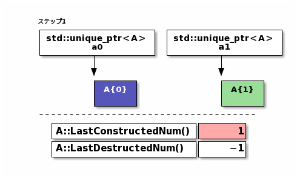

```cpp
    // @@@ example/term_explanation/unique_ptr_ownership_ut.cpp 57

    // ステップ1
    // a0、a1がそれぞれ初期化される。
    auto a0 = std::make_unique<A>(0);           // a0はA{0}を所有
    auto a1 = std::make_unique<A>(1);           // a1はA{1}を所有

    ASSERT_EQ(1,  A::LastConstructedNum());     // A{1}は生成された
    ASSERT_EQ(-1, A::LastDestructedNum());      // まだ、A::~A()は呼ばれてない
```

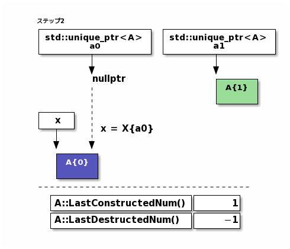

```cpp
    // @@@ example/term_explanation/unique_ptr_ownership_ut.cpp 67

    // ステップ2
    // xが生成され、オブジェクトA{0}の所有がa0からxへ移動する。
    ASSERT_EQ(0, a0->GetNum());                 // a0はA{0}を所有
    auto x = X{std::move(a0)};                  // xの生成と、a0からxへA{0}の所有権の移動
    ASSERT_FALSE(a0);                           // a0は何も所有していない
```

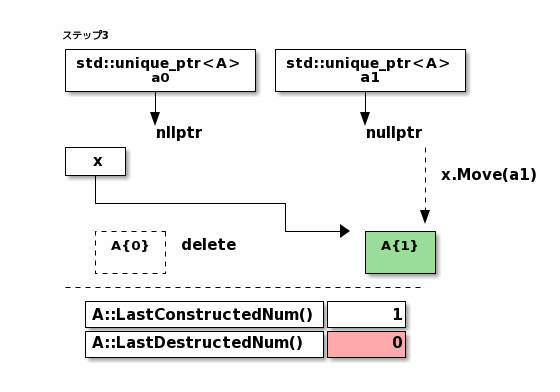

```cpp
    // @@@ example/term_explanation/unique_ptr_ownership_ut.cpp 75

    // ステップ3
    // オブジェクトA{1}の所有がa1からxへ移動する。
    // xは以前保持していたA{0}オブジェクトへのポインタをdeleteするため
    // (std::unique_ptrによる自動delete)、A::LastDestructedNum()の値が0になる。
    ASSERT_EQ(1, a1->GetNum());                 // a1はA{1}を所有
    x.Move(std::move(a1));                      // xによるA{0}の解放
                                                // a1からxへA{1}の所有権の移動
    ASSERT_EQ(0, A::LastDestructedNum());       // A{0}は解放された
    ASSERT_FALSE(a1);                           // a1は何も所有していない
    ASSERT_EQ(1, x.GetA()->GetNum());           // xはA{1}を所有
```

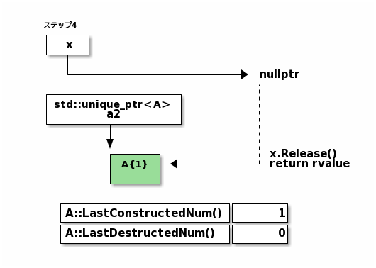

```cpp
    // @@@ example/term_explanation/unique_ptr_ownership_ut.cpp 88

    // ステップ4
    // x.ptr_はstd::unique_ptr<A>であるため、ステップ3の状態では、
    // x.ptr_はA{1}オブジェクトのポインタを保持しているが、
    // x.Release()はそれをrvalueに変換し戻り値にする。
    // その戻り値をa2で受け取るため、A{1}の所有はxからa2に移動する。
    std::unique_ptr<A> a2{x.Release()};         // xからa2へA{1}の所有権の移動
    ASSERT_EQ(nullptr, x.GetA());               // xは何も所有していない
    ASSERT_EQ(1, a2->GetNum());                 // a2はA{1}を所有
```

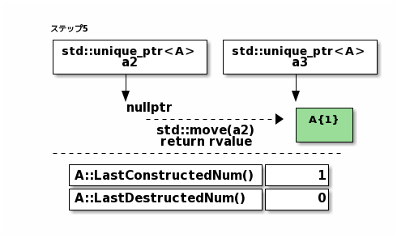

```cpp
    // @@@ example/term_explanation/unique_ptr_ownership_ut.cpp 99

    // ステップ5
    // a2をstd::move()によりrvalueに変換し、ブロック内のa3に渡すことで、
    // A{1}の所有はa2からa3に移動する。
    {
        std::unique_ptr<A> a3{std::move(a2)};
        ASSERT_FALSE(a2);                       // a2は何も所有していない
        ASSERT_EQ(1, a3->GetNum());             // a3はA{1}を所有
```

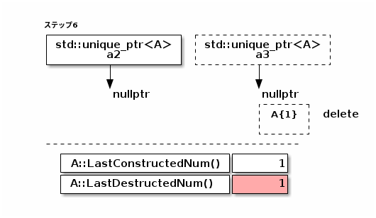

```cpp
    // @@@ example/term_explanation/unique_ptr_ownership_ut.cpp 109

        // ステップ6
        // このブロックが終了することで、std::unique_ptrであるa3のデストラクタが呼び出される。
        // これはA{1}オブジェクトへのポインタをdeleteする。
    }                                      // a3によるA{1}の解放
    ASSERT_EQ(1, A::LastDestructedNum());  // A{1}が解放されたことの確認
```

また、以下に見るようにstd::unique_ptrはcopy生成やcopy代入を許可しない。

```cpp
    // @@@ example/term_explanation/unique_ptr_ownership_ut.cpp 123

    auto a0 = std::make_unique<A>(0);

    // auto a1 = a0;                            // 下記のようなメッセージでコンパイルエラー
    //      unique_ptr_ownership_ut.cpp:125:15: error: use of deleted function ‘std::unique_ptr ...

    auto a1 = std::move(a0);                    // すでに示したようにmove生成は可能

    auto a2 = std::unique_ptr<A>{};

    // a2 = a1;                                 // 下記のようなメッセージでコンパイルエラー
    //      unique_ptr_ownership_ut.cpp:131:10: error: use of deleted function ‘std::unique_ptr ...

    a2 = std::move(a1);                         // すでに示したようにmove代入は可能

    //
    auto x0 = X{std::make_unique<A>(0)};

    // auto x1 = x0;                            // Xはstd::unique_ptrをメンバとするため、
                                                // デフォルトのcopyコンストラクタによる生成は
                                                // コンパイルエラー
    auto x1 = std::move(x0);                    // デフォルトのmove生成は可能

    auto x2 = X{std::make_unique<A>(0)};

    // x2 = x1;                                 // Xはstd::unique_ptrをメンバとするため、
                                                // デフォルトのcopy代入子の呼び出しは
                                                // コンパイルエラー
    x2 = std::move(x1);                         // デフォルトのmove代入は可能
```

以上で示したstd::unique_ptrの仕様の要点をまとめると、以下のようになる。

- std::unique_ptrはダイナミックに生成されたオブジェクトを保持する。
- ダイナミックに生成されたオブジェクトを保持するstd::unique_ptrがスコープアウトすると、 保持中のオブジェクトは自動的にdeleteされる。
- 保持中のオブジェクトを他のstd::unique_ptrにmoveすることはできるが、 copyすることはできない。このため、下記に示すような不正な方法以外で、 複数のstd::unique_ptrが1つのオブジェクトを共有することはできない。

```cpp
    // @@@ example/term_explanation/unique_ptr_ownership_ut.cpp 161

    // 以下のようなコードを書いてはならない

    auto a0 = std::make_unique<A>(0);
    auto a1 = std::unique_ptr<A>{a0.get()};  // a1もa0が保持するオブジェクトを保持するが、
                                             // 保持されたオブジェクトは二重解放される

    auto a_ptr = new A{0};

    auto a2 = std::unique_ptr<A>{a_ptr};
    auto a3 = std::unique_ptr<A>{a_ptr};  // a3もa2が保持するオブジェクトを保持するが、
                                          // 保持されたオブジェクトは二重解放される
```

こういった機能によりstd::unique_ptrはオブジェクトの排他所有を実現している。

#### オブジェクトの共有所有

オブジェクトの共有所有や、それを容易に実現するための [std::shared_ptr](https://cpprefjp.github.io/reference/memory/shared_ptr.html) の仕様をを説明するために、下記のようにクラスA、Xを定義する。

```cpp
    // @@@ example/term_explanation/shared_ptr_ownership_ut.cpp 7

    class A final {
    public:
        explicit A(int32_t n) noexcept : num_{n} { last_constructed_num_ = num_; }
        ~A() { last_destructed_num_ = num_; }

        int32_t GetNum() const noexcept { return num_; }

        static int32_t LastConstructedNum() noexcept { return last_constructed_num_; }
        static int32_t LastDestructedNum() noexcept { return last_destructed_num_; }

    private:
        int32_t const  num_;
        static int32_t last_constructed_num_;
        static int32_t last_destructed_num_;
    };

    int32_t A::last_constructed_num_ = -1;
    int32_t A::last_destructed_num_  = -1;

    class X final {
    public:
        // Xオブジェクトの生成と、ptrからptr_へ所有権の移動もしくは共有
        explicit X(std::shared_ptr<A> ptr) : ptr_{std::move(ptr)} {}

        // ptrからptr_へ所有権の移動
        void Move(std::shared_ptr<A>&& ptr) noexcept { ptr_ = std::move(ptr); }

        int32_t UseCount() const noexcept { return ptr_.use_count(); }

        A const* GetA() const noexcept { return ptr_ ? ptr_.get() : nullptr; }

    private:
        std::shared_ptr<A> ptr_{};
    };
```

下記に示した上記クラスの単体テストにより、 オブジェクトの所有権やその移動、共有、 std::shared_ptr、std::move()、rvalueの関係を解説する。

```cpp
    // @@@ example/term_explanation/shared_ptr_ownership_ut.cpp 47

    // ステップ0
    // まだ、クラスAオブジェクトは生成されていないため、
    // A::LastConstructedNum()、A::LastDestructedNum()は初期値である-1である。
    ASSERT_EQ(-1, A::LastConstructedNum());     // まだ、A::A()は呼ばれてない
    ASSERT_EQ(-1, A::LastDestructedNum());      // まだ、A::~A()は呼ばれてない
```

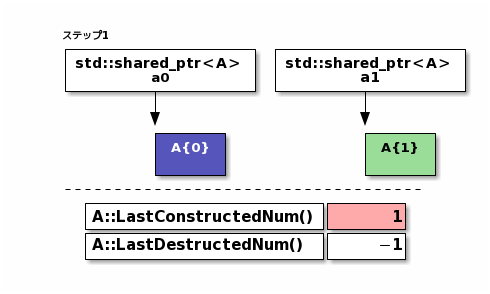

```cpp
    // @@@ example/term_explanation/shared_ptr_ownership_ut.cpp 56

    // ステップ1
    // a0、a1がそれぞれ初期化される。
    auto a0 = std::make_shared<A>(0);           // a0はA{0}を所有
    auto a1 = std::make_shared<A>(1);           // a1はA{1}を所有
    ASSERT_EQ(1, a0.use_count());               // A{0}の共有所有カウント数は1
    ASSERT_EQ(1, a1.use_count());               // A{1}の共有所有カウント数は1

    ASSERT_EQ(1,  A::LastConstructedNum());     // A{1}は生成された
    ASSERT_EQ(-1, A::LastDestructedNum());      // まだ、A::~A()は呼ばれてない
```

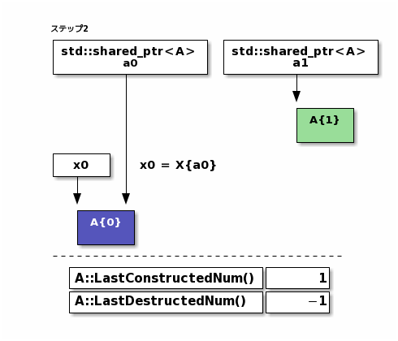

```cpp
    // @@@ example/term_explanation/shared_ptr_ownership_ut.cpp 68

    // ステップ2
    // x0が生成され、オブジェクトA{0}がa0とx0に共同所有される。
    ASSERT_EQ(0, a0->GetNum());                 // a0はA{0}を所有
    ASSERT_EQ(1, a0.use_count());               // A{0}の共有所有カウントは1
    auto x0 = X{a0};                            // x0の生成と、a0とx0によるA{0}の共有所有
    ASSERT_EQ(2, a0.use_count());               // A{0}の共有所有カウント数は2
    ASSERT_EQ(2, x0.UseCount());
    ASSERT_EQ(x0.GetA(), a0.get());
```

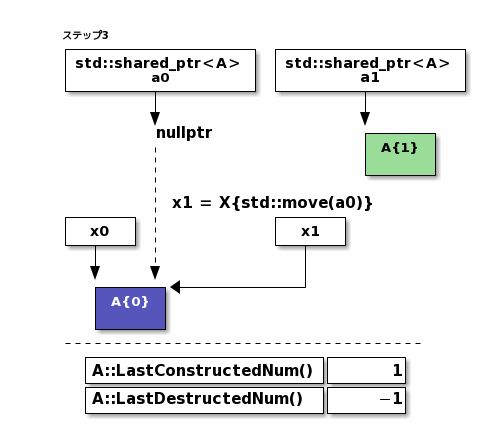

```cpp
    // @@@ example/term_explanation/shared_ptr_ownership_ut.cpp 79

    // ステップ３
    // x1が生成され、オブジェクトA{0}の所有がa0からx1へ移動する。
    auto x1 = X{std::move(a0)};                 // x1の生成と、a0からx1へA{0}の所有権の移動
    ASSERT_EQ(x1.GetA(), x1.GetA());            // x0、x1がA{0}を共有所有
    ASSERT_EQ(2, x0.UseCount());                // A{0}の共有所有カウント数は2
    ASSERT_EQ(2, x1.UseCount());
    ASSERT_FALSE(a0);                           // a0は何も所有していない
```

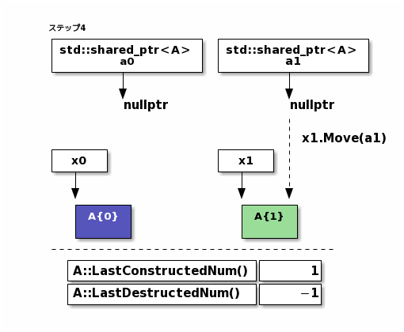

```cpp
    // @@@ example/term_explanation/shared_ptr_ownership_ut.cpp 89

    // ステップ４
    // オブジェクトA{1}の所有がa1からx1へ移動する。
    // この時、x1::ptr_は下記のような手順で以前保持していたA{0}オブジェクトへの所有を放棄する。
    //  1. x1::ptr_の共有所有カウント(ptr_.use_count()の戻り値)をデクリメント
    //  2. 共有所有カウントが0ならば、ptr_で保持しているオブジェクト(この場合、A{0})をdelete
    //  3. x1::ptr_の管理対象をに新規オブジェクト(この場合、A{1})に変更
    //
    // ここでは、x0::ptr_がA{0}を所有しているため、共有所有カウントは1であり、
    // 従って、A{0}はdeleteされず、A::LastDestructedNum()の値は-1のまま。
    ASSERT_EQ(1, a1->GetNum());                 // a1はA{1}を所有
    ASSERT_EQ(0, x1.GetA()->GetNum());          // x1はA{0}を所有
    ASSERT_EQ(2, x1.UseCount());                // A{0}の共有所有カウント数は２
    x1.Move(std::move(a1));                     // x1はA{0}の代わりに、A{1}を所有
                                                // a1からx1へA{1}の所有権の移動
    ASSERT_EQ(-1, A::LastDestructedNum());      // x0がA{0}を所有するため、A{0}は未解放
    ASSERT_FALSE(a1);                           // a1は何も所有していない
    ASSERT_EQ(1, x1.GetA()->GetNum());          // x1はA{1}を所有
    ASSERT_EQ(1, x1.UseCount());                // A{0}の共有所有カウント数は1
```

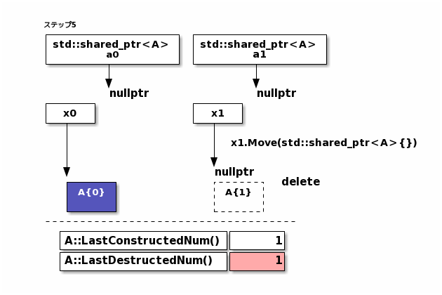

```cpp
    // @@@ example/term_explanation/shared_ptr_ownership_ut.cpp 110

    // ステップ５
    // 現時点でx1はA{1}オブジェクトを保持している。
    // x1::Moveに空のstd::shared_ptrを渡すことにより、A{1}を解放する。
    x1.Move(std::shared_ptr<A>{});              // x1に空のstd::shared_ptr<A>を代入することで、
                                                // A{1}を解放
    ASSERT_EQ(nullptr, x1.GetA());              // x1は何も保持していない
    ASSERT_EQ(1, A::LastDestructedNum());       // A{1}が解放された
```

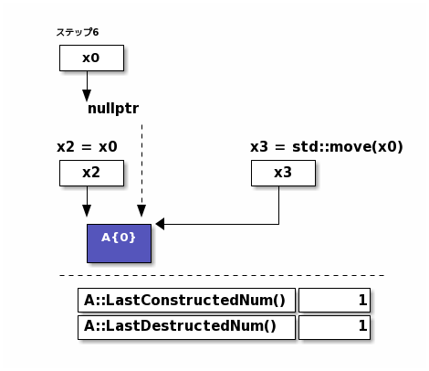

```cpp
    // @@@ example/term_explanation/shared_ptr_ownership_ut.cpp 120

    // ステップ６
    // 現時点でx0はA{0}オブジェクトを保持している。
    //
    // ここでは、x0からx2、x3をそれぞれcopy、move生成し、
    // この次のステップ７では、x2、x3がスコープアウトすることでA{0}を解放する。
    {
        ASSERT_EQ(0, x0.GetA()->GetNum());      // x0はA{0}を所有
        ASSERT_EQ(1, x0.UseCount());            // A{0}の共有所有カウント数は1
        auto x2 = x0;                           // x0からx2をcopy生成
        ASSERT_EQ(x0.GetA(), x2.GetA());
        ASSERT_EQ(2, x0.UseCount());            // A{0}の共有所有カウント数は２

        auto x3 = std::move(x0);                // x0からx2をmove生成、x0はA{0}の所有を放棄
        ASSERT_EQ(nullptr, x0.GetA());
        ASSERT_EQ(0, x2.GetA()->GetNum());      // x2はA{0}を保有
        ASSERT_EQ(x2.GetA(), x3.GetA());        // x2、x3はA{0}を共有保有
        ASSERT_EQ(2, x2.UseCount());            // A{1}の共有所有カウント数は２
```

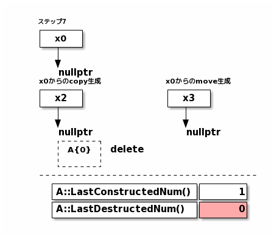

```cpp
    // @@@ example/term_explanation/shared_ptr_ownership_ut.cpp 142

        // ステップ７
        // このブロックが終了することで、x2、x3はスコープアウトする。
        // デストラクタ呼び出しの順序はコンストラクタ呼び出しの逆になるため、
        // 最初にx3::~X()が呼び出され、この延長でx3::ptr_のデストラクタが呼び出される。
        // これによりA{0}のの共有所有カウントは1になる。
        // 次にx2::~X()が呼び出され、この延長でx2::ptr_のデストラクタが呼び出される。
        // これによりA{0}のの共有所有カウントは0になり、A{0}はdeleteされる。
        //
    }   // x2、x3のスコープアウト
    ASSERT_EQ(0, A::LastDestructedNum());  // A{0}が解放された
```

以上で示したstd::shared_ptrの仕様の要点をまとめると、以下のようになる。

- std::shared_ptrはダイナミックに生成されたオブジェクトを保持する。
- ダイナミックに生成されたオブジェクトを保持するstd::shared_ptrがスコープアウトすると、 共有所有カウントはデクリメントされ、その値が0ならば保持しているオブジェクトはdeleteされる。
- std::shared_ptrを他のstd::shared_ptrに、
  - moveすることことで、保持中のオブジェクトの所有権を移動できる。
  - copyすることことで、保持中のオブジェクトの所有権を共有できる。
- 下記のようなコードはstd::shared_ptrの仕様が想定するセマンティクスに沿っておらず、 未定義動作に繋がる。

```cpp
    // @@@ example/term_explanation/shared_ptr_ownership_ut.cpp 162

    // 以下のようなコードを書いてはならない

    auto a0 = std::make_shared<A>(0);
    auto a1 = std::shared_ptr<A>{a0.get()};  // a1もa0が保持するオブジェクトを保持するが、
                                             // 保持されたオブジェクトは二重解放される

    auto a_ptr = new A{0};

    auto a2 = std::shared_ptr<A>{a_ptr};
    auto a3 = std::shared_ptr<A>{a_ptr};  // a3もa2が保持するオブジェクトを保持するが、
                                          // 保持されたオブジェクトは二重解放される
```

こういった機能によりstd::shared_ptrはオブジェクトの共有所有を実現している。

### オブジェクトのライフタイム

オブジェクトは、以下のような種類のライフタイムを持つ。

- 静的に生成されたオブジェクトのライフタイム
- thread_localに生成されたオブジェクトのライフタイム
- newで生成されたオブジェクトのライフタイム
- スタック上に生成されたオブジェクトのライフタイム
- prvalue(「rvalue」参照)のライフタイム

なお、リファレンスの初期化をrvalueで行った場合、 そのrvalueはリファレンスがスコープを抜けるまで存続し続ける。

### クラスのレイアウト

クラス(やそのクラスが継承した基底クラス)が仮想関数を持たない場合、 そのクラスは、非静的なメンバ変数が定義された順にメモリ上に配置されたレイアウトを持つ (CPUアーキテクチャに依存したパディング領域が変数間に挿入されることもある)。 このようなクラスはPOD (C++20では、[PODという用語は非推奨](https://cpprefjp.github.io/lang/cpp20/deprecate_pod.html) となり、トリビアル型とスタンダードレイアウト型に用語が分割された)とも呼ばれ、 C言語の構造体のレイアウトと互換性を持つことが一般的である。

クラス(やそのクラスが継承したクラス)が仮想関数を持つ場合、 仮想関数呼び出しを行う(「オーバーライドとオーバーロードの違い」参照) ためのメモリレイアウトが必要になる。 それを示すために、まずは下記のようにクラスX、Y、Zを定義する。

```cpp
    // @@@ example/term_explanation/class_layout_ut.cpp 4

    class X {
    public:
        virtual int64_t GetX() { return x_; }
        virtual ~X() {}

    private:
        int64_t x_{1};
    };

    class Y : public X {
    public:
        virtual int64_t GetX() override { return X::GetX() + y_; }
        virtual int64_t GetY() { return y_; }
        virtual ~Y() override {}

    private:
        int64_t y_{2};
    };

    class Z : public Y {
    public:
        virtual int64_t GetX() override { return Y::GetX() + z_; }
        virtual int64_t GetY() override { return Y::GetY() + z_; }
        virtual int64_t GetZ() { return z_; }
        virtual ~Z() override {}

    private:
        int64_t z_{3};
    };
```

通常のC++コンパイラが作り出すX、Y、Zの概念的なメモリレイアウトは下記のようになる。

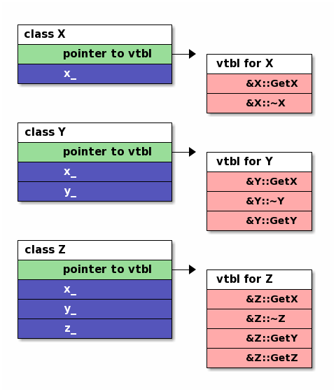

各クラスがvtblへのポインタを保持するため、このドキュメントで使用しているg++では、 sizeof(X)は8ではなく16、sizeof(Y)は16ではなく24、sizeof(Z)は24ではなく32となる。

g++の場合、以下のオプションを使用し、クラスのメモリレイアウトをファイルに出力することができる。

```cpp
    // @@@ example/term_explanation/Makefile 19

    CCFLAGS_ADD:=-fdump-lang-class
```

X、Y、Zのメモリレイアウトは以下の様に出力される。

```
    Vtable for X
    X::_ZTV1X: 5 entries
    0     (int (*)(...))0
    8     (int (*)(...))(& _ZTI1X)
    16    (int (*)(...))X::GetX
    24    (int (*)(...))X::~X
    32    (int (*)(...))X::~X

    Class X
       size=16 align=8
       base size=16 base align=8
    X (0x0x7f54bbc23a80) 0
        vptr=((& X::_ZTV1X) + 16)

    Vtable for Y
    Y::_ZTV1Y: 6 entries
    0     (int (*)(...))0
    8     (int (*)(...))(& _ZTI1Y)
    16    (int (*)(...))Y::GetX
    24    (int (*)(...))Y::~Y
    32    (int (*)(...))Y::~Y
    40    (int (*)(...))Y::GetY

    Class Y
       size=24 align=8
       base size=24 base align=8
    Y (0x0x7f54bbc3f000) 0
        vptr=((& Y::_ZTV1Y) + 16)
      X (0x0x7f54bbc23d20) 0
          primary-for Y (0x0x7f54bbc3f000)

    Vtable for Z
    Z::_ZTV1Z: 7 entries
    0     (int (*)(...))0
    8     (int (*)(...))(& _ZTI1Z)
    16    (int (*)(...))Z::GetX
    24    (int (*)(...))Z::~Z
    32    (int (*)(...))Z::~Z
    40    (int (*)(...))Z::GetY
    48    (int (*)(...))Z::GetZ

    Class Z
       size=32 align=8
       base size=32 base align=8
    Z (0x0x7f54bbc3f068) 0
        vptr=((& Z::_ZTV1Z) + 16)
      Y (0x0x7f54bbc3f0d0) 0
          primary-for Z (0x0x7f54bbc3f068)
        X (0x0x7f54bbc43060) 0
            primary-for Y (0x0x7f54bbc3f0d0)
```

このようなメモリレイアウトは、

```cpp
    // @@@ example/term_explanation/class_layout_ut.cpp 40

    auto z_ptr = new Z;
```

のようなオブジェクト生成に密接に関係する。その手順を下記の疑似コードにより示す。

```cpp
    // ステップ1  メモリアロケーション
    void* ptr = malloc(sizeof(Z));

    // ステップ2  ZオブジェクトのX部分の初期化
    X* x_ptr = (X*)ptr;
    x_ptr->vtbl = &vtbl_for_X       // Xのコンストラクタ呼び出し処理
    x_ptr->x_ = 1;                  // Xのコンストラクタ呼び出し処理

    // ステップ3  ZオブジェクトのY部分の初期化
    Y* y_ptr = (Y*)ptr;
    y_ptr->vtbl = &vtbl_for_Y       // Yのコンストラクタ呼び出し処理
    y_ptr->y_ = 2;                  // Yのコンストラクタ呼び出し処理

    // ステップ4  ZオブジェクトのZ部分の初期化
    Z* z_ptr = (Z*)ptr;
    z_ptr->vtbl = &vtbl_for_Z       // Zのコンストラクタ呼び出し処理
    z_ptr->z_ = 3;                  // Zのコンストラクタ呼び出し処理
```

オブジェクトの生成がこのように行われるため、Xのコンストラクタ内で仮想関数GetX()を呼び出した場合、 その時のvtblへのポインタはXのvtblを指しており(上記ステップ2)、X::GetX()の呼び出しとなる (Z::GetX()の呼び出しとはならない)。

なお、オブジェクトの解放は生成とは逆の順番で行われる。

## オブジェクトのコピー

### シャローコピー

シャローコピー(浅いコピー)とは、暗黙的、 もしくは=defaultによってコンパイラが生成するようなcopyコンストラクタ、 copy代入演算子が行うコピーであり、ディープコピーと対比的に使われる概念である。

以下のクラスShallowOKには、コンパイラが生成するcopyコンストラクタ、 copy代入演算子と同等なものを定義したが、これは問題のないシャローコピーである (が、正しく自動生成される関数を実装すると、メンバ変数が増えた際にバグを生み出すことがあるため、 実践的にはこのようなことはすべきではない)。

```cpp
    // @@@ example/term_explanation/deep_shallow_copy_ut.cpp 7

    class ShallowOK {
    public:
        explicit ShallowOK(char const* str = "") : str_{std::string{str}} {}
        std::string const& GetString() const noexcept { return str_; }

        // 下記2関数を定義しなければ、以下と同等なcopyコンストラクタ、copy代入演算子が定義される。
        ShallowOK(ShallowOK const& rhs) : str_{rhs.str_} {}

        ShallowOK& operator=(ShallowOK const& rhs)
        {
            str_ = rhs.str_;
            return *this;
        }

    private:
        std::string str_;
    };
```

コンストラクタでポインタのようなリソースを確保し、 デストラクタでそれらを解放するようなクラスの場合、シャローコピーは良く知られた問題を起こす。

下記のShallowNGはその例である。

```cpp
    // @@@ example/term_explanation/deep_shallow_copy_ut.cpp 43

    class ShallowNG {
    public:
        explicit ShallowNG(char const* str = "") : str_{new std::string{str}} {}
        ~ShallowNG() { delete str_; }
        std::string const& GetString() const noexcept { return *str_; }

    private:
        std::string* str_;
    };
```

シャローコピーにより、メンバで保持していたポインタ(ポインタが指しているオブジェクトではない) がコピーされてしまうため、下記のコード内のコメントで示した通り、 メモリリークや2重解放を起こしてしまう。

```cpp
    // @@@ example/term_explanation/deep_shallow_copy_ut.cpp 60

    auto const s0 = ShallowNG{"s0"};

    // NG s0.str_とs1.str_は同じメモリを指すため~ShallowNG()に2重解放される。
    auto const s1 = ShallowNG{s0};

    auto s2 = ShallowNG{"s2"};

    // NG s2.str_が元々保持していたメモリは、解放できなくなる。
    s2 = s0;

    // NG s0.str_とs2.str_は同じメモリを指すため、
    //    s0、s2のスコープアウト時に、~ShallowNG()により、2重解放される。
```

### ディープコピー

ディープコピーとは、シャローコピーが発生させる問題を回避したコピーである。

以下に例を示す。

```cpp
    // @@@ example/term_explanation/deep_shallow_copy_ut.cpp 79

    class Deep {
    public:
        explicit Deep(char const* str = "") : str_{new std::string{str}} {}
        ~Deep() { delete str_; }
        std::string const& GetString() const noexcept { return *str_; }

        // copyコンストラクタの実装例
        Deep(Deep const& rhs) : str_{new std::string{*rhs.str_}} {}

        // copy代入演算子の実装例
        Deep& operator=(Deep const& rhs)
        {
            *str_ = *(rhs.str_);
            return *this;
        }

    private:
        std::string* str_;
    };

    class Deep2 {  // std::unique_ptrを使いDeepをリファクタリング
    public:
        explicit Deep2(char const* str = "") : str_{std::make_unique<std::string>(str)} {}
        std::string const& GetString() const { return *str_; }

        // copyコンストラクタの実装例
        Deep2(Deep2 const& rhs) : str_{std::make_unique<std::string>(*rhs.str_)} {}

        // copy代入演算子の実装例
        Deep2& operator=(Deep2 const& rhs)
        {
            *str_ = *(rhs.str_);
            return *this;
        }

    private:
        std::unique_ptr<std::string> str_;
    };
```

上記クラスのDeepは、copyコンストラクタ、copy代入演算子でポインタをコピーするのではなく、 ポインタが指しているオブジェクトを複製することにより、シャローコピーの問題を防ぐ。

### スライシング

オブジェクトのスライシングとは、

- クラスBaseとその派生クラスDerived
- クラスDerivedのインスタンスd1、d2(解説のために下記例ではd0も定義)
- d2により初期化されたBase&型のd2_ref(クラスBase型のリファレンス)

が宣言されたとした場合、

```cpp
    d2_ref = d1;    // オブジェクトの代入
```

を実行した時に発生するようなオブジェクトの部分コピーのことである (この問題はリファレンスをポインタに代えた場合にも起こる)。

以下のクラスと単体テストはこの現象を表している。

```cpp
    // @@@ example/term_explanation/slice_ut.cpp 10

    class Base {
    public:
        explicit Base(char const* name) noexcept : name0_{name} {}
        char const* Name0() const noexcept { return name0_; }

        ...
    private:
        char const* name0_;
    };

    class Derived final : public Base {
    public:
        Derived(char const* name0, char const* name1) noexcept : Base{name0}, name1_{name1} {}
        char const* Name1() const noexcept { return name1_; }

        ...
    private:
        char const* name1_;
    };

    TEST(Slicing, reference)
    {
        auto const d0     = Derived{"d0", "d0"};
        auto const d1     = Derived{"d1", "d1"};
        auto       d2     = Derived{"d2", "d2"};
        Base&      d2_ref = d2;

        ASSERT_STREQ("d2", d2.Name0());  // OK
        ASSERT_STREQ("d2", d2.Name1());  // OK

        d2 = d0;
        ASSERT_STREQ("d0", d2.Name0());  // OK
        ASSERT_STREQ("d0", d2.Name1());  // OK

        d2_ref = d1;                     // d2_refはBase&型で、d2へのリファレンス
        ASSERT_STREQ("d1", d2.Name0());  // OK
    #if 0
        ASSERT_STREQ("d1", d2.Name1());  // 本来ならこうなってほしいが、
    #else
        ASSERT_STREQ("d0", d2.Name1());  // スライシングの影響でDerived::name1_はコピーされない
    #endif
    }
```

copy代入演算子(=)によりコピーが行われた場合、=の両辺のオブジェクトは等価になるべきだが (copy代入演算子をオーバーロードした場合も、そうなるように定義すべきである)、 スライシングが起こった場合、そうならないことが問題である(「等価性のセマンティクス」参照)。

下記にこの現象の発生メカニズムについて解説する。

1. 上記クラスBase、Derivedのメモリ上のレイアウトは下記のようになる。

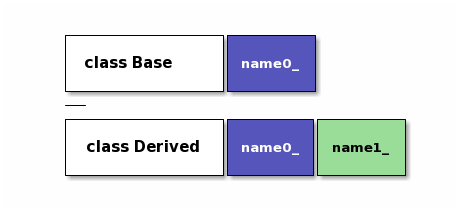

2. 上記インスタンスd0、d1、d2、d2_refのメモリ上のレイアウトは下記のようになる。

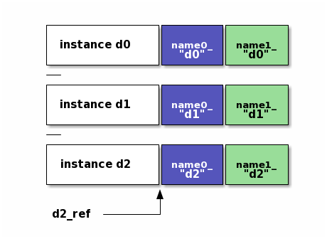

3. d2 = d0をした場合の状態は下記のようになる。

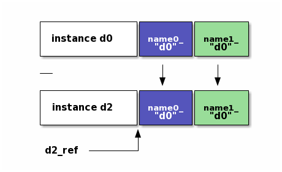

4. 上記の状態でd2_ref = d1をした場合の状態は下記のようになる。

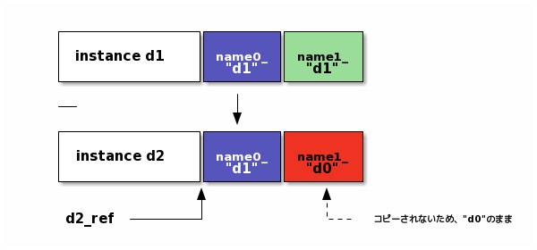

d2.name1_の値が元のままであるが(これがスライシングである)、その理由は下記の疑似コードが示す通り、 「d2_refの表層型がクラスBaseであるためd1もクラスBase(正確にはBase型へのリファレンス)へ変換された後、 d2_refが指しているオブジェクト(d2)へコピーされた」からである。

```cpp
    d2_ref.Base::operator=(d1);   // Base::operator=(Base const&)が呼び出される
```

次に示すのは、 「オブジェクトの配列をその基底クラスへのポインタに代入し、 そのポインタを配列のように使用した場合に発生する」スライシングと類似の現象である。

```cpp
    // @@@ example/term_explanation/slice_ut.cpp 61

    TEST(Slicing, array)
    {
        Derived d_array[]{{"0", "1"}, {"2", "3"}};
        Base*   b_ptr = d_array;  // この代入までは問題ないが、b_ptr[1]でのアクセスで問題が起こる

        ASSERT_STREQ("0", d_array[0].Name0());  // OK
        ASSERT_STREQ("0", b_ptr[0].Name0());    // OK

        ASSERT_STREQ("2", d_array[1].Name0());  // OK
    #if 0  // スライシングに類似した問題で、以下のテストは失敗する。
        ASSERT_STREQ("2", b_ptr[1].Name0());  // NG
    #else  // こうすればテストは通るが、、、
        ASSERT_STREQ("1", b_ptr[1].Name0());  // NG
    #endif
    }
```

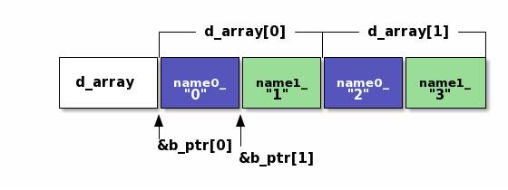

## name lookupと名前空間

ここではname lookupとそれに影響を与える名前空間について解説する。

### ルックアップ

このドキュメントでのルックアップとはname lookupを指す。

### name lookup

[name lookup](https://en.cppreference.com/w/cpp/language/lookup) とはソースコードで名前が検出された時に、その名前をその宣言と関連付けることである。 以下、name lookupの例を上げる。

下記のようなコードがあった場合、

```cpp
    // @@@ example/term_explanation/name_lookup_ut.cpp 5

    namespace NS_LU {
    int f() noexcept { return 0; }
    }  // namespace NS_LU
```

以下のコードでの関数呼び出しf()のname lookupは、

```cpp
    // @@@ example/term_explanation/name_lookup_ut.cpp 29

    NS_LU::f();
```

1. NS_LUをその前方で宣言された名前空間と関連付けする
2. f()呼び出しをその前方の名前空間NS_LUで宣言された関数fと関連付ける

という手順で行われる。

下記のようなコードがあった場合、

```cpp
    // @@@ example/term_explanation/name_lookup_ut.cpp 11

    namespace NS_LU {
    bool g(int i) noexcept { return i < 0; }

    char g(std::string_view str) noexcept { return str[0]; }

    template <typename T, size_t N>
    size_t g(T const (&)[N]) noexcept
    {
        return N;
    }
```

以下のコードでの関数呼び出しg()のname lookupは、

```cpp
    // @@@ example/term_explanation/name_lookup_ut.cpp 37
    int a[3]{1, 2, 3};
    NS_LU::g(a);
```

1. NS_LUをその前方で宣言された名前空間と関連付けする
2. 名前空間NS_LU内で宣言された複数のgを見つける
3. g()呼び出しを、 すでに見つけたgの中からベストマッチしたg(T const (&)[N])と関連付ける

という手順で行われる。

下記記のようなコードがあった場合、

```cpp
    // @@@ example/term_explanation/name_lookup_ut.cpp 44

    // グローバル名前空間
    std::string ToString(int i) { return std::to_string(i) + " in Global"; }

    namespace NS_LU {
    struct X {
        int i;
    };

    std::string ToString(X const& x) { return std::to_string(x.i) + " in NS_LU"; }
    }  // namespace NS_LU

    namespace NS2 {
    std::string ToString(NS_LU::X const& x) { return std::to_string(x.i) + " in NS2"; }
    }  // namespace NS2
```

以下のコードでの関数呼び出しToString()のname lookupは、

```cpp
    // @@@ example/term_explanation/name_lookup_ut.cpp 65

    auto x = NS_LU::X{1};

    ASSERT_EQ("1 in NS_LU", ToString(x));
```

1. ToString()呼び出しの引数xの型Xが名前空間NS_LUで定義されているため、 ToStringを探索する名前空間にNS_LUを組み入れる(「関連名前空間」参照)
2. ToString()呼び出しより前方で宣言されたグローバル名前空間とNS_LUの中から、 複数のToStringの定義を見つける
3. ToString()呼び出しを、 すでに見つけたToStringの中からベストマッチしたNS_LU::ToStringと関連付ける

という手順で行われる。

### two phase name lookup

[two phase name lookup](https://en.cppreference.com/w/cpp/language/two-phase_lookup) とはテンプレートをインスタンス化するときに使用される、下記のような2段階でのname lookupである。

1. テンプレート定義内でname lookupを行う(通常のname lookupと同じ)。 この時、テンプレートパラメータに依存した名前 (dependent_name)は name lookupの対象外となる(name lookupの対象が確定しないため)。
2. 1の後、テンプレートパラメータを展開した関数内で、 関連名前空間の宣言も含めたname lookupを行う。

以下の議論では、

- 上記1のname lookupを1st name lookup
- 上記2のname lookupを2nd name lookup

と呼ぶことにする。

下記のようなコードがあった場合、

```cpp
    // @@@ example/term_explanation/two_phase_name_lookup_ut.cpp 5

    namespace NS_TPLU {
    struct X {
        int i;
    };
    }  // namespace NS_TPLU

    // グローバル名前空間
    inline std::string ToType(NS_TPLU::X const&) { return "X in global"; }
    inline std::string ToType(int const&) { return "int in global"; }

    // 再びNS_TPLU
    namespace NS_TPLU {

    std::string Header(long) { return "type:"; }  //  下記にもオーバーロードあり

    template <typename T>
    std::string ToType(T const&)  //  下記にもオーバーロードあり
    {
        return "unknown";
    }

    template <typename T>
    std::string TypeName(T const& t)  // オーバーロードなし
    {
        return Header(int{}) + ToType(t);
    }

    std::string Header(int) { return "TYPE:"; }  // 上記にもオーバーロードあり

    std::string ToType(X const&) { return "X"; }      // 上記にもオーバーロードあり
    std::string ToType(int const&) { return "int"; }  // 上記にもオーバーロードあり
    }  // namespace NS_TPLU
```

以下のコードでのTypeNameのインスタンス化に伴うname lookupは、

```cpp
    // @@@ example/term_explanation/two_phase_name_lookup_ut.cpp 44

    auto x = NS_TPLU::X{1};

    ASSERT_EQ("type:X", TypeName(x));
```

1. TypeName()呼び出しの引数xの型Xが名前空間NS_TPLUで宣言されているため、 NS_TPLUをTypeNameを探索する関連名前空間にする。
2. TypeName()呼び出しより前方で宣言されたグローバル名前空間とNS_TPLUの中からTypeNameを見つける。
3. TypeNameは関数テンプレートであるためtwo phase lookupが以下のように行われる。
   1. TypeName内でのHeader(int{})の呼び出しは、1st name lookupにより、 Header(long)の宣言と関連付けられる。 Header(int)はHeader(long)よりもマッチ率が高い、 TypeNameの定義より後方で宣言されているため、name lookupの対象外となる。
   2. TypeName内でのToType(t)の呼び出しに対しては、2nd name lookupが行われる。 このためTypeName定義より前方で宣言されたグローバル名前空間と、 tの型がNS_TPLU::Xであるため関連名前空間となったNS_TPLUがname lookupの対象となるが、 グローバル名前空間内のToTypeは、 NS_TPLU内でTypeNameより前に宣言されたtemplate<> ToTypeによってname-hidingが起こり、 TypeNameからは非可視となるためname lookupの対象から外れる。 このため、ToType(t)の呼び出しは、NS_TPLU::ToType(X const&)の宣言と関連付けられる。

という手順で行われる。

上と同じ定義、宣言がある場合の以下のコードでのTypeNameのインスタンス化に伴うname lookupは、

```cpp
    // @@@ example/term_explanation/two_phase_name_lookup_ut.cpp 50

    ASSERT_EQ("type:unknown", NS_TPLU::TypeName(int{}));
```

1. NS_TPLUを名前空間と関連付けする (引数の型がintなのでNS_TPLUは関連名前空間とならず、NS_TPLUを明示する必要がある)。
2. TypeName()呼び出しより前方で宣言されたNS_TPLUの中からTypeNameを見つける。
3. TypeNameは関数テンプレートであるためtwo phase lookupが以下のように行われる。
   1. TypeName内でのHeader(int{})の呼び出しは、1st name lookupにより、 前例と同じ理由で、Header(long)の宣言と関連付けられる。
   2. TypeName内でのToType(t)の呼び出しに対しては、2nd name lookupが行われる。 tの型がintであるためNS_TPLUは関連名前空間とならず、通常のname lookupと同様に ToType(t)の呼び出し前方のグローバル名前空間とNS_TPLUがname lookupの対象になるが、 グローバル名前空間内のToTypeは、 NS_TPLU内でTypeNameより前に宣言されたtemplate<> ToTypeによってname-hidingが起こり、 TypeNameからは非可視となるためname lookupの対象から外れる。 また、ToType(int const&)は、TypeNameの定義より後方で宣言されているため、 name lookupの対象外となり、 その結果、ToType(t)の呼び出しは、NS_TPLU内のtemplate<> ToTypeの宣言と関連付けられる。

という手順で行われる。

以上の理由から、先に示した例でのToTypeの戻り値は”X”となり、 後に示した例でのToTypeの戻り値は”unknown”となる。 これはtwo phase lookupの結果であり、 two phase lookupが実装されていないコンパイラ(こういったコンパイラは存在する)では、 結果が異なるため注意が必要である (本ドキュメントではこのような問題をできる限り避けるために、 サンプルコードをg++とclang++でコンパイルしている)。

以下に、two phase lookupにまつわるさらに驚くべきコード例を紹介する。 上と同じ定義、宣言がある場合の以下のコードの動作を考える。

```cpp
    // @@@ example/term_explanation/two_phase_name_lookup_ut.cpp 54

    ASSERT_EQ("type:long", NS_TPLU::TypeName(long{}));
```

NS_TPLU::TypeName(int{})のintをlongにしただけなので、この単体テストはパスしないが、 この単体テストコードの後(実際にはこのファイルのコンパイル単位の中のNS_TPLU内で、 且つtemplate<> ToTypeの宣言の後方であればどこでもよい) に以下のコードを追加するとパスしてしまう。

```cpp
    // @@@ example/term_explanation/two_phase_name_lookup_ut.cpp 61

    namespace NS_TPLU {
    template <>
    std::string ToType<long>(long const&)
    {
        return "long";
    }
    }  // namespace NS_TPLU
```

この理由は、関数テンプレート内での2nd name lookupで選択された名前が関数テンプレートであった場合、 その特殊化の検索範囲はコンパイル単位内になることがあるからである (template_specialization によるとこの動作は未定義のようだが、 g++/clang++両方ともこのコードを警告なしでコンパイルする)。

TypeName(long{})内でのtwo phase name lookupは、TypeName(int{})とほぼ同様に進み、 template<> ToTypeの宣言を探し出すが、 さらに前述したようにこのコンパイル単位のNS_TPLU内からその特殊化も探し出す。 その結果、ToType(t)の呼び出しは、NS_TPLU内のtemplate<> ToType<long>の定義と関連付けられる。

以上の議論からわかる通り、関数テンプレートとその特殊化の組み合わせは、 そのインスタンス化箇所(この場合単体テストコード内)の後方から、 name lookupでバインドされる関数を変更することができるため、 極めて分かりづらいコードを生み出す。ここから、

- 関数テンプレートとその特殊化はソースコード上なるべく近い位置で宣言するべきである
- STL関数テンプレートの特殊化は行うべきではない

という教訓が得られる。

なお、関数とその関数オーバーロードのname lookupの対象は、呼び出し箇所前方の宣言のみであるため、 関数テンプレートToType(T const& t)の代わりに、関数ToType(…)を使うことで、 上記問題は回避可能である。

次に示す例は、一見2nd name lookupで関連付けされるように見える関数ToType(NS_TPLU2::Y const&)が、 実際には関連付けされないコードである。

```cpp
    // @@@ example/term_explanation/two_phase_name_lookup_ut.cpp 71

    namespace NS_TPLU2 {
    struct Y {
        int i;
    };
    }  // namespace NS_TPLU2
```

```cpp
    // @@@ example/term_explanation/two_phase_name_lookup_ut.cpp 79

    // global名前空間
    template <typename T>
    std::string ToType(T const&)
    {
        return "unknown";
    }

    template <typename T>
    std::string TypeName(T const& t)
    {
        return "type:" + ToType(t);
    }

    std::string ToType(NS_TPLU2::Y const&) { return "Y"; }
```

これは先に示したNS_TPLU::Xの例と極めて似ている。本質的な違いは、 TypeNameやToTypeがグローバル名前空間で宣言されていることのみである。 だが、下記の単体テストで示す通り、 TypeName内でのname lookupで関数オーバーライドToType(NS_TPLU2::Y const&)が選択されないのである。

```cpp
    // @@@ example/term_explanation/two_phase_name_lookup_ut.cpp 100

    auto y = NS_TPLU2::Y{1};

    // ASSERT_EQ("type:Y", TypeName(y));
    ASSERT_EQ("type:unknown", TypeName(y));  // ToType(NS_TPLU2::Y const&)は使われない
```

ここまでの現象を正確に理解するには、 「two phase lookupの対象となる宣言」を下記のように、より厳密に認識する必要がある。

- TypeNameの中で行われる1st name lookupの対象となる宣言は下記の積集合である。
  - TypeNameと同じ名前空間内かグローバル名前空間内の宣言
  - TypeName定義位置より前方の宣言
- TypeNameの中で行われる2nd name lookupの対象となる宣言は下記の和集合である。
  - 1st name lookupで使われた宣言
  - TypeName呼び出しより前方にある関連名前空間内の宣言

この認識に基づくNS_TPLU2::Yに対するグローバルなTypeName内でのtwo phase name lookupは、

1. TypeName内に1st name lookupの対象がないため何もしない。
2. TypeName内の2nd name lookupに使用される関連名前空間NS_TPLU2は、 ToType(NS_TPLU2::Y const&)の宣言を含まないため、この宣言は2nd name lookupの対象とならない。 その結果、ToType(t)の呼び出しは関数テンプレートToType(T const&)と関連付けられる。

という手順で行われる。

以上が、TypeNameからToType(NS_TPLU2::Y const&)が使われない理由である。

ここまでで示したようにtwo phase name lookupは理解しがたく、 理解したとしてもその使いこなしはさらに難しい。

次のコードは、この難解さに翻弄されるのが現場のプログラマのみではないことを示す。

```cpp
    // @@@ example/term_explanation/two_phase_name_lookup_ut.cpp 71

    namespace NS_TPLU2 {
    struct Y {
        int i;
    };
    }  // namespace NS_TPLU2
```

```cpp
    // @@@ example/term_explanation/two_phase_name_lookup_ut.cpp 110

    // global名前空間
    template <typename T>
    int operator+(T const&, int i)
    {
        return i;
    }

    template <typename T>
    int TypeNum(T const& t)
    {
        return t + 0;
    }

    int operator+(NS_TPLU2::Y const& y, int i) { return y.i + i; }
```

上記の宣言、定義があった場合、operator+の単体テストは以下のようになる。

```cpp
    // @@@ example/term_explanation/two_phase_name_lookup_ut.cpp 132

    auto y = NS_TPLU2::Y{1};

    ASSERT_EQ(1, y + 0);  // 2つ目のoperator+が選択される
```

このテストは当然パスするが、次はどうだろう？

```cpp
    // @@@ example/term_explanation/two_phase_name_lookup_ut.cpp 142

    auto y = NS_TPLU2::Y{1};

    ASSERT_EQ(1, TypeNum(y));  // g++ではoperator+(NS_TPLU2::Y const&, int i)がname lookupされる
```

これまでのtwo phase name lookupの説明では、 operator+(NS_TPLU2::Y const& y, int i)はTypeNum内でのname lookupの対象にはならないため、 このテストはエラーとならなければならないが、g++ではパスしてしまう。 2nd name lookupのロジックにバグがあるようである。

有難いことに、clang++では仕様通りこのテストはエラーとなり、 当然ながら以下のテストはパスする(つまり、g++ではエラーする)。

```cpp
    // @@@ example/term_explanation/two_phase_name_lookup_ut.cpp 151

    auto y = NS_TPLU2::Y{1};

    ASSERT_EQ(0, TypeNum(y));  // clang++ではoperator+(T const&, int i)がname lookupされる
```

なお、TypeNum内のコードである

```cpp
    return t + 0;
```

を下記のように変更することで

```cpp
    return operator+(t, 0);
```

g++のname lookupはclang++と同じように動作するため、 記法に違和感があるものの、この方法はg++のバグのワークアランドとして使用できる。

また、operator+(NS_TPLU2::Y const& y, int i)をNS_TPLU2で宣言することで、 g++ではパスしたテストをclang++でもパスさせられるようになる(これは正しい動作)。 これにより、型とその2項演算子オーバーロードは同じ名前空間で宣言するべきである、 という教訓が得られる。

以上で見てきたようにtwo phase name lookupは、現場プログラマのみではなく、 コンパイラを開発するプログラマをも混乱させるほど難解ではあるが、 STLを含むテンプレートメタプログラミングを支える重要な機能であるため、 C++プログラマには、最低でもこれを理解し、出来れば使いこなせるようになってほしい。

### 実引数依存探索

実引数依存探索とは、argument-dependent lookupの和訳語であり、 通常はその略語であるADLと呼ばれる。

### ADL

ADLとは、関数の実引数の型が宣言されている名前空間(これを関連名前空間と呼ぶ)内の宣言が、 その関数のname lookupの対象になることである。

下記のようなコードがあった場合、

```cpp
    // @@@ example/term_explanation/name_lookup_adl_ut.cpp 5
    namespace NS_ADL {
    struct A {
        int i;
    };

    std::string ToString(A const& a) { return std::string{"A:"} + std::to_string(a.i); }
    }  // namespace NS_ADL
```

以下のコードでのToStringの呼び出しに対するのname lookupは、

```cpp
    // @@@ example/term_explanation/name_lookup_adl_ut.cpp 18

    auto a = NS_ADL::A{0};

    ASSERT_EQ("A:0", ToString(a));  // ADLの効果により、ToStringはNS_ADLを指定しなくても見つかる
```

- ToStringの呼び出しより前方で行われているグローバル名前空間内の宣言
- ToStringの呼び出しより前方で行われているNS_ADL内の宣言

の両方を対象として行われる。 NS_ADL内の宣言がToStringの呼び出しに対するのname lookupの対象になる理由は、 ToStringの呼び出しに使われている実引数aの型AがNS_ADLで宣言されているからである。 すでに述べたようにこれをADLと呼び、この場合のNS_ADLを関連名前空間と呼ぶ。

ADLは思わぬname lookupによるバグを誘発することもあるが、 下記コードを見れば明らかなように、また、 多くのプログラマはそれと気づかずに使っていることからもわかる通り、 コードをより自然に、より簡潔に記述するための重要な機能となっている。

```cpp
    // @@@ example/term_explanation/name_lookup_adl_ut.cpp 28

    // 下記operator <<は、std::operator<<(ostream&, string const&)であり、
    // namespace stdで定義されている。

    // ADLがあるため、operator <<は名前空間修飾無しで呼び出せる。
    std::cout << std::string{__func__};

    // ADLが無いと下記のような呼び出しになる。
    std::operator<<(std::cout, std::string{__func__});
```

### 関連名前空間

関連名前空間(associated namespace)とは、 ADL(実引数依存探索)によってname lookupの対象になった宣言を含む名前空間のことである。

### SFINAE

[SFINAE](https://cpprefjp.github.io/lang/cpp11/sfinae_expressions.html) (Substitution Failure Is Not An Errorの略称、スフィネェと読む)とは、 「テンプレートのパラメータ置き換えに失敗した(ill-formedになった)際に、 即時にコンパイルエラーとはせず、置き換えに失敗したテンプレートを name lookupの候補から除外する」 という言語機能である。

### name-hiding

name-hidingとは 「前方の識別子が、その後方に同一の名前をもつ識別子があるために、 name lookupの対象外になる」現象一般をを指す通称である (namespace参照)。

まずは、クラスとその派生クラスでのname-hidingの例を示す。

```cpp
    // @@@ example/term_explanation/name_hiding.cpp 4

    struct Base {
        void f() noexcept {}
    };

    struct Derived : Base {
        // void f(int) { f(); }     // f()では、Baseのf()をname lookupできないため、
        void f(int) noexcept { Base::f(); }  // Base::でf()を修飾した
    };
```

上記の関数fは一見オーバーロードに見えるが、そうではない。下記のコードで示したように、 Base::f()には、修飾しない形式でのDerivedクラス経由のアクセスはできない。

```cpp
    // @@@ example/term_explanation/name_hiding.cpp 18

    {
        auto d = Derived{};
    #if 0
        d.f(); // コンパイルできない
    #else
        d.Base::f();  // Base::での修飾が必要
    #endif
    }
```

これは前述したように、 Base::fがその後方にあるDerived::f(int)によりname-hidingされたために起こる現象である (name lookupによる探索には識別子が使われるため、シグネチャの違いはname-hidingに影響しない)。

下記のようにusing宣言を使用することで、 修飾しない形式でのDerivedクラス経由のBase::f()へのアクセスが可能となる。

```cpp
    // @@@ example/term_explanation/name_hiding.cpp 34

    struct Derived : Base {
        using Base::f;  // using宣言によりDerivedにBase::fを導入
        void f(int) noexcept { Base::f(); }
    };
```

```cpp
    // @@@ example/term_explanation/name_hiding.cpp 45

    auto d = Derived{};
    d.f();  // using宣言によりコンパイルできる
```

下記コードは、名前空間でも似たような現象が起こることを示している。

```cpp
    // @@@ example/term_explanation/name_hiding.cpp 54

    // global名前空間
    void f() noexcept {}

    namespace NS_A {
    void f(int) noexcept {}

    void g() noexcept
    {
    #if 0
        f();  // NS_A::fによりname-hidingされたため、コンパイルできない
    #endif
    }
    }  // namespace NS_A
```

この問題に対しては、下記のようにf(int)の定義位置を後方に移動することで回避できる。

```cpp
    // @@@ example/term_explanation/name_hiding.cpp 70

    namespace NS_A_fixed_0 {
    void g() noexcept
    {
        // グローバルなfの呼び出し
        f();  // NS_A::fは後方に移動されたためコンパイルできる
    }

    void f(int) noexcept {}
    }  // namespace NS_A_fixed_0
```

また、先述のクラスでの方法と同様にusing宣言を使い、下記のようにすることもできる。

```cpp
    // @@@ example/term_explanation/name_hiding.cpp 82

    namespace NS_A_fixed_1 {
    void f(int) noexcept {}

    void g() noexcept
    {
        using ::f;

        // グローバルなfの呼び出し
        f();  // using宣言によりコンパイルできる
    }
    }  // namespace NS_A_fixed_1
```

当然ながら、下記のようにf()の呼び出しを::で修飾することもできる。

```cpp
    // @@@ example/term_explanation/name_hiding.cpp 96

    namespace NS_A_fixed_2 {
    void f(int) noexcept {}

    void g() noexcept
    {
        // グローバルなfの呼び出し
        ::f();  // ::で修飾すればコンパイルできる
    }
    }  // namespace NS_A_fixed_2
```

修飾の副作用として「two phase name lookup」の例で示したような ADLを利用した高度な静的ディスパッチが使用できなくなるが、 通常のソフトウェア開発では、ADLが必要な場面は限られているため、 デフォルトでは名前空間を使用して修飾を行うことにするのが、 無用の混乱をさけるための安全な記法であると言えるだろう。

次に、そういった混乱を引き起こすであろうコードを示す。

```cpp
    // @@@ example/term_explanation/name_hiding.cpp 108

    namespace NS_B {
    struct S_in_B {};

    void f(S_in_B) noexcept {}
    void f(int) noexcept {}

    namespace NS_B_Inner {
    void g() noexcept
    {
        f(int{});  // コンパイルでき、NS_B::f(int)が呼ばれる
    }

    void f() noexcept {}

    void h() noexcept
    {
        // f(int{});     // コンパイルできない
        NS_B::f(int{});  // 名前空間で修飾することでコンパイルできる

        f(S_in_B{});  // ADLによりコンパイルできる
    }
    }  // namespace NS_B_Inner
    }  // namespace NS_B
```

NS_B_Inner::g()内のf(int)の呼び出しはコンパイルできるが、 name-hidingが原因で、NS_B_Inner::h()内のf(int)の呼び出しはコンパイルできず、 名前空間で修飾することが必要になる。 一方で、ADLの効果で名前空間での修飾をしていないf(S_in_B)の呼び出しはコンパイルできる。

全チームメンバがこういったname lookupを正しく扱えると確信できないのであれば、 前述の通り、デフォルトでは名前空間を使用して修飾を行うのが良いだろう。

### ドミナンス

ドミナンス(Dominance、支配性)とは、 「探索対称の名前が継承の中にも存在するような場合のname lookupの仕様の一部」 を指す慣用句である。

以下に

- ダイヤモンド継承を含まない場合
- ダイヤモンド継承かつそれが仮想継承でない場合
- ダイヤモンド継承かつそれが仮想継承である場合

のドミナンスについてのコードを例示する。

この例で示したように、ダイヤモンド継承を通常の継承で行うか、 仮想継承で行うかでは結果が全く異なるため、注意が必要である。

#### ダイヤモンド継承を含まない場合

```cpp
    // @@@ example/term_explanation/dominance_ut.cpp 9

    int32_t f(double) noexcept { return 0; }

    struct Base {
        int32_t f(int32_t) const noexcept { return 1; }
        int32_t f(double) const noexcept { return 2; }
    };

    struct Derived : Base {
        int32_t f(int32_t) const noexcept { return 3; }  // Base::fを隠蔽する(name-hiding)
    };

    struct DerivedDerived : Derived {
        int32_t g() const noexcept { return f(2.14); }
    };
```

```cpp
    // @@@ example/term_explanation/dominance_ut.cpp 29

    Base b;

    ASSERT_EQ(2, b.f(2.14));  // オーバーロード解決により、B::f(double)が呼ばれる

    DerivedDerived dd;

    // Derivedのドミナンスにより、B::fは、DerivedDerived::gでのfのname lookupの対象にならず、
    // DerivedDerived::gはDerived::fを呼び出す。
    ASSERT_EQ(3, dd.g());
```

このname lookupについては、name-hidingで説明した通りである。

#### ダイヤモンド継承かつそれが仮想継承でない場合

```cpp
    // @@@ example/term_explanation/dominance_ut.cpp 45

    struct Base {
        int32_t f(int32_t) const noexcept { return 1; }
        int32_t f(double) const noexcept { return 2; }
    };

    struct Derived_0 : Base {
        int32_t f(int32_t) const noexcept { return 3; }  // Base::fを隠蔽する(name-hiding)
    };

    struct Derived_1 : Base {};

    struct DerivedDerived : Derived_0, Derived_1 {
        int32_t g() const noexcept { return f(2.14); }  // Derived_0::f or Derived_1::f ?
    };

    // dominance_ut.cpp:58:41: error: reference to ‘f’ is ambiguous
    //    58 |     int32_t g() const noexcept { return f(2.14); }  // Derived_0::f or Derived_1::f ?
    //       |                                         ^
```

上記コードはコードブロック内のコメントのようなメッセージが原因でコンパイルできない。

Derived_0のドミナンスにより、DerivedDerived::gはDerived_0::fを呼び出すように見えるが、 もう一つの継承元であるDerived_1が導入したDerived_1::f(実際には、Derived_1::Base::f)があるため、 Derived_1によるドミナンスも働き、その結果として、呼び出しが曖昧(ambiguous)になることで、 このような結果となる。

#### ダイヤモンド継承かつそれが仮想継承である場合

```cpp
    // @@@ example/term_explanation/dominance_ut.cpp 71

    struct Base {
        int32_t f(int32_t) const noexcept { return 1; }
        int32_t f(double) const noexcept { return 2; }
    };

    struct Derived_0 : virtual Base {
        int32_t f(int32_t) const noexcept { return 3; }  // Base::fを隠蔽する(name-hiding)
    };

    struct Derived_1 : virtual Base {};

    struct DerivedDerived : Derived_0, Derived_1 {
        int32_t g() const noexcept { return f(2.14); }
    };
```

```cpp
    // @@@ example/term_explanation/dominance_ut.cpp 92

    DerivedDerived dd;

    // Derived_0のドミナンスと仮想継承の効果により、
    // B::fは、DerivedDerived::gでのfのname lookupの対象にならず、
    // DerivedDerived::gはDerived_0::fを呼び出す。
    ASSERT_EQ(3, dd.g());
```

これまでと同様にDerived_0のドミナンスによりBase::fはname-hidingされることになる。 この時、Derived_0、Derived_1がBaseから仮想継承した効果により、 この継承ヒエラルキーの中でBaseは１つのみ存在することになるため、 Derived_1により導入されたBase::fも併せてname-hidingされる。 結果として、曖昧性は排除され、コンパイルエラーにはならず、このような結果となる。

### ダイヤモンド継承

ダイヤモンド継承(Diamond Inheritance)とは、以下のような構造のクラス継承を指す。

- 基底クラス(Base)が一つ存在し、その基底クラスから二つのクラス(Derived_0、Derived_1)が派生する。
- Derived_0とDerived_1からさらに一つのクラス(DerivedDerived)が派生する。 したがって、DerivedDerivedはBaseの孫クラスとなる。

この継承は、多重継承の一形態であり、クラス図で表すと下記のようになるため、 ダイヤモンド継承と呼ばれる。

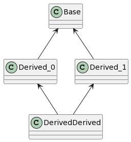

ダイヤモンド継承は、 仮想継承(virtual inheritance)を使ったものと、使わないものに分類できる。

仮想継承を使わないダイヤモンド継承のコードを以下に示す。

```cpp
    // @@@ example/term_explanation/diamond_inheritance_ut.cpp 6

    class Base {
    public:
        int32_t get() const noexcept { return x_; }
        void    set(int32_t x) noexcept { x_ = x; }

    private:
        int32_t x_ = 0;
    };

    class Derived_0 : public Base {};

    class Derived_1 : public Base {};

    class DerivedDerived : public Derived_0, public Derived_1 {};
```

```cpp
    // @@@ example/term_explanation/diamond_inheritance_ut.cpp 26

    auto dd = DerivedDerived{};

    Base& b0 = static_cast<Derived_0&>(dd);  // Derived_0::Baseのリファレンス
    Base& b1 = static_cast<Derived_1&>(dd);  // Derived_1::Baseのリファレンス

    ASSERT_NE(&b0, &b1);  // ddの中には、Baseインスタンスが2つできる
```

これからわかるように、DerivedDerivedインスタンスの中に2つのBaseインスタンスが存在する。

下記コードは、それが原因で名前解決が曖昧になりコンパイルできない。

```cpp
    // @@@ example/term_explanation/diamond_inheritance_ut.cpp 36

    Base& b = dd;  // Derived_0::Base or Derived_1::Base ?

    dd.get();  // Derived_0::get or  Derived_1::get ?

    // 下記のようなエラーが発生する
    //  diamond_inheritance_ut.cpp:37:15: error: ‘Base’ is an ambiguous base of ‘DerivedDerived’
    //     37 |     Base& b = dd;  // Derived_0::Base or Derived_1::Base ?
    //        |               ^~
    //  diamond_inheritance_ut.cpp:39:8: error: request for member ‘get’ is ambiguous
    //     39 |     dd.get();  // Derived_0::get or  Derived_1::get ?
    //        |        ^~~
```

この問題に対処するには、クラス名による修飾が必要になるが、 Baseインスタンスが2つ存在するため、下記に示すようなわかりづらいバグの温床となる。

```cpp
    // @@@ example/term_explanation/diamond_inheritance_ut.cpp 53

    ASSERT_EQ(0, dd.Derived_0::get());  // クラス名による名前修飾
    ASSERT_EQ(0, dd.Derived_1::get());

    dd.Derived_0::set(1);
    ASSERT_EQ(1, dd.Derived_0::get());  // Derived_0::Base::x_は1に変更
    ASSERT_EQ(0, dd.Derived_1::get());  // Derived_1::Base::x_は0のまま

    dd.Derived_1::set(2);
    ASSERT_EQ(1, dd.Derived_0::get());  // Derived_0::Base::x_は1のまま
    ASSERT_EQ(2, dd.Derived_1::get());  // Derived_1::Base::x_は2に変更
```

次に示すのは、仮想継承を使用したダイヤモンド継承の例である。

```cpp
    // @@@ example/term_explanation/diamond_inheritance_ut.cpp 70

    class Base {
    public:
        int32_t get() const noexcept { return x_; }
        void    set(int32_t x) noexcept { x_ = x; }

    private:
        int32_t x_ = 0;
    };

    class Derived_0 : public virtual Base {};  // 仮想継承

    class Derived_1 : public virtual Base {};  // 仮想継承

    class DerivedDerived : public Derived_0, public Derived_1 {};
```

```cpp
    // @@@ example/term_explanation/diamond_inheritance_ut.cpp 90

    auto dd = DerivedDerived{};

    Base& b0 = static_cast<Derived_0&>(dd);  // Derived_0::Baseのリファレンス
    Base& b1 = static_cast<Derived_1&>(dd);  // Derived_1::Baseのリファレンス

    ASSERT_EQ(&b0, &b1);  // ddの中には、Baseインスタンスが1つできる
```

仮想継承の効果で、DerivedDerivedインスタンスの中に存在するBaseインスタンスは1つになるため、 上で示した仮想継承を使わないダイヤモンド継承での問題は解消される (が、仮想継承による別の問題が発生する)。

```cpp
    // @@@ example/term_explanation/diamond_inheritance_ut.cpp 99

    Base& b = dd;  // Baseインスタンスは1つであるため、コンパイルできる

    dd.get();  // Baseインスタンスは1つであるため、コンパイルできる

    dd.Derived_0::set(1);               // クラス名による修飾
    ASSERT_EQ(1, dd.Derived_1::get());  // Derived_1::BaseとDerived_1::Baseは同一であるため

    dd.set(2);
    ASSERT_EQ(2, dd.get());
```

### 仮想継承

下記に示した継承方法を仮想継承、仮想継承の基底クラスを仮想基底クラスと呼ぶ。

```cpp
    // @@@ example/term_explanation/virtual_inheritance_ut.cpp 9

    class Base {
    public:
        explicit Base(int32_t x = 0) noexcept : x_{x} {}
        int32_t get() const noexcept { return x_; }

    private:
        int32_t x_;
    };

    class DerivedVirtual : public virtual Base {  // 仮想継承
    public:
        explicit DerivedVirtual(int32_t x) noexcept : Base{x} {}
    };
```

仮想継承は、ダイヤモンド継承の基底クラスのインスタンスを、 その継承ヒエラルキーの中で1つのみにするための言語機能である。

仮想継承の独特の動作を示すため、 上記コードに加え、仮想継承クラス、通常の継承クラス、 それぞれを通常の継承したクラスを下記のように定義する。

```cpp
    // @@@ example/term_explanation/virtual_inheritance_ut.cpp 25

    class DerivedDerivedVirtual : public DerivedVirtual {  // 仮想継承を通常の継承
    public:
        explicit DerivedDerivedVirtual(int32_t x) noexcept : DerivedVirtual{x} {}
    };

    class DerivedNormal : public Base {  // 通常の継承
    public:
        explicit DerivedNormal(int32_t x) noexcept : Base{x} {}
    };

    class DerivedDerivedNormal : public DerivedNormal {  // 通常の継承を通常の継承
    public:
        explicit DerivedDerivedNormal(int32_t x) noexcept : DerivedNormal{x} {}
    };
```

この場合、継承ヒエラルキーに仮想継承を含むクラスと、含まないクラスでは、 以下に示したような違いが発生する。

```cpp
    // @@@ example/term_explanation/virtual_inheritance_ut.cpp 45

    auto dv = DerivedVirtual{1};  // 仮想継承クラス
    auto dn = DerivedNormal{1};   // 通常の継承クラス

    ASSERT_EQ(1, dv.get());  // これは非仮想継承と同じ動作
    ASSERT_EQ(1, dn.get());

    auto ddv = DerivedDerivedVirtual{1};  // 仮想継承クラスを継承したクラス
    auto ddn = DerivedDerivedNormal{1};   // 通常の継承クラスを継承したクラス

    ASSERT_EQ(0, ddv.get());  // Baseのデフォルトコンストラクタが呼ばれる
    ASSERT_EQ(1, ddn.get());
```

これは、「仮想継承クラスを継承したクラスが、 仮想継承クラスの基底クラスのコンストラクタを明示的に呼び出さない場合、 引数なしで呼び出せる基底クラスのコンストラクタが呼ばれる」仕様に起因している (引数なしで呼び出せる基底クラスのコンストラクタがない場合はコンパイルエラー)。 以下では、これを「仮想継承のコンストラクタ呼び出し」仕様と呼ぶことにする。

仮想継承クラスが、基底クラスのコンストラクタを呼び出したとしても、この仕様が優先されるため、 上記コードのような動作となる。

これを通常の継承クラスと同様な動作にするには、下記のようにしなければならない。

```cpp
    // @@@ example/term_explanation/virtual_inheritance_ut.cpp 61

    class DerivedDerivedVirtualFixed : public DerivedVirtual {  // DerivedDerivedNormalと同じように動作
    public:
        explicit DerivedDerivedVirtualFixed(int32_t x) noexcept : Base{x}, DerivedVirtual{x} {}
        //                     基底クラスのコンストラクタ呼び出し ^^^^^^^
    };
```

```cpp
    // @@@ example/term_explanation/virtual_inheritance_ut.cpp 72

    DerivedDerivedVirtual ddv{1};  // 仮想継承クラスを継承したクラス
    DerivedDerivedVirtualFixed ddvf{1};  // 上記クラスのコンストラクタを修正したクラス
    DerivedDerivedNormal ddn{1};         // 通常の継承クラスを継承したクラス

    ASSERT_EQ(0, ddv.get());  // 仮想継承独特の動作
    ASSERT_EQ(1, ddvf.get());
    ASSERT_EQ(1, ddn.get());
```

「仮想継承のコンストラクタ呼び出し」仕様は、 ダイヤモンド継承での基底クラスのコンストラクタ呼び出しを一度にするために存在する。

もし、この機能がなければ、下記のコードでの基底クラスのコンストラクタ呼び出しは2度になるため、 デバッグ困難なバグが発生してしまうことは容易に想像できるだろう。

```cpp
    // @@@ example/term_explanation/virtual_inheritance_ut.cpp 87

    int32_t base_called;

    class Base {
    public:
        explicit Base(int32_t x = 0) noexcept : x_{x} { ++base_called; }
        int32_t get() const noexcept { return x_; }

    private:
        int32_t x_;
    };

    class Derived_0 : public virtual Base {  // 仮想継承
    public:
        explicit Derived_0(int32_t x) noexcept : Base{x} { assert(base_called == 1); }
    };

    class Derived_1 : public virtual Base {  // 仮想継承
    public:
        explicit Derived_1(int32_t x) noexcept : Base{x} { assert(base_called == 1); }
    };

    class DerivedDerived : public Derived_0, public Derived_1 {
    public:
        DerivedDerived(int32_t x0, int32_t x1) noexcept : Derived_0{x0}, Derived_1{x1} {}
        // 「仮想継承のコンストラクタ呼び出し」仕様がなければ、このコンストラクタは、
        //    Base::Base -> Derived_0::Derived_0 ->
        //      Base::Base -> Derived_0::Derived_0 ->
        //        DerivedDerived::DerivedDerived
        //  という呼び出しになるため、Base::Baseが2度呼び出されてしまう。
    };
```

```cpp
    // @@@ example/term_explanation/virtual_inheritance_ut.cpp 123

    ASSERT_EQ(0, base_called);

    auto dd = DerivedDerived{2, 3};  // Base::Baseが最初に呼ばれないとassertion failする

    ASSERT_EQ(1, base_called);  // 「仮想継承のコンストラクタ呼び出し」仕様のため
    ASSERT_EQ(0, dd.get());  // Baseのデフォルトコンストラクタは、x_を0にする
```

基底クラスのコンストラクタ呼び出しは、下記のコードのようにした場合でも、 単体テストが示すように、一番最初に行われる。

```cpp
    // @@@ example/term_explanation/virtual_inheritance_ut.cpp 138

    class DerivedDerived : public Derived_0, public Derived_1 {
    public:
        DerivedDerived(int32_t x0, int32_t x1) noexcept : Derived_0{x0}, Derived_1{x1}, Base{1} {}
    };
```

```cpp
    // @@@ example/term_explanation/virtual_inheritance_ut.cpp 150

    ASSERT_EQ(0, base_called);

    auto dd = DerivedDerived{2, 3};  // Base::Baseが最初に呼ばれないとassertion failする

    ASSERT_EQ(1, base_called);  // 「仮想継承のコンストラクタ呼び出し」仕様のため
    ASSERT_EQ(1, dd.get());  // Base{1}呼び出しの効果
```

このため、基底クラスのコンストラクタ呼び出しは下記のような順番で行うべきである。

```cpp
    // @@@ example/term_explanation/virtual_inheritance_ut.cpp 163

    class DerivedDerived : public Derived_0, public Derived_1 {
    public:
        DerivedDerived(int32_t x0, int32_t x1) noexcept : Base{1}, Derived_0{x0}, Derived_1{x1} {}
    };
```

### 仮想基底

仮想基底(クラス)とは、仮想継承の基底クラス指す。

### using宣言

using宣言とは、“using XXX::func”のような記述である。 この記述が行われたスコープでは、この記述後の行から名前空間XXXでの修飾をすることなく、 funcが使用できる。

```cpp
    // @@@ example/term_explanation/namespace_ut.cpp 6
    namespace XXX {
    void func() noexcept {}
    void gunc() noexcept {}
    }  // namespace XXX
```

```cpp
    // @@@ example/term_explanation/namespace_ut.cpp 12

    // global namespace
    void using_declaration() noexcept
    {
        using XXX::func;  // using宣言

        func();       // XXX::不要
        XXX::gunc();  // XXX::必要
    }
```

### usingディレクティブ

usingディレクティブとは、“using namespace XXX”のような記述である。 この記述が行われたスコープでは、下記例のように、この記述後から名前空間XXXでの修飾をすることなく、 XXXの識別子が使用できる。

```cpp
    // @@@ example/term_explanation/namespace_ut.cpp 6
    namespace XXX {
    void func() noexcept {}
    void gunc() noexcept {}
    }  // namespace XXX
```

```cpp
    // @@@ example/term_explanation/namespace_ut.cpp 24

    // global namespace
    void using_directive() noexcept
    {
        using namespace XXX;  // usingディレクティブ

        func();  // XXX::不要
        gunc();  // XXX::不要
    }
```

より多くの識別子が名前空間の修飾無しで使えるようになる点において、 using宣言よりも危険であり、また、 下記のようにname-hidingされた識別子の導入には効果がない。

```cpp
    // @@@ example/term_explanation/namespace_ut.cpp 6
    namespace XXX {
    void func() noexcept {}
    void gunc() noexcept {}
    }  // namespace XXX
```

```cpp
    // @@@ example/term_explanation/namespace_ut.cpp 35

    namespace XXX_Inner {
    void func(int) noexcept {}
    void using_declaration() noexcept
    {
    #if 0
        using namespace XXX;  // name-hidingのため効果がない
    #else
        using XXX::func;  // using宣言
    #endif

        func();  // XXX::不要
    }
```

従って、usingディレクティブの使用は避けるべきである。

## expressionと値カテゴリ

ここでは、expression(式)の値カテゴリや、それに付随した機能についての解説を行う。

### expression

C++においてexpression、lvalue、rvalue、xvalue、glvalue、prvalueは以下のように定められている。

- [expression](https://ja.cppreference.com/w/cpp/language/expressions)(式) とは「演算子とそのオペランドの並び」である(オペランドのみの記述も式である)。 演算子とは以下のようなものである。
  - 四則演算、代入(a = b、a += b …)、インクリメント、比較、論理式
  - 明示的キャストや型変換
  - メンバアクセス(a.b、a->b、a[x]、 *a、&a …)
  - 関数呼び出し演算子(f(…))、sizeof、decltype等
- expressionは、以下のいずれかに分類される。lvalueでないexpressionがrvalueである。
  - lvalue
  - rvalue
- lvalueとは、関数もしくはオブジェクトを指す。
- rvalueは、以下のいずれかに分類される。
  - xvalue
  - prvalue
- xvalueとは以下のようなものである。
  - 戻り値の型がT&&(Tは任意の型)である関数の呼び出し式(std::move(x))
  - オブジェクトへのT&&へのキャスト式(static_cast<char&&>(x))
  - aを配列のrvalueとした場合のa[N]や、 cをクラス型のrvalueとした場合のc.m(mはaの非staticメンバ)等
- prvalueとは、オブジェクトやビットフィールドを初期化する、 もしくはオペランドの値を計算する式であり、以下のようなものである。
  - 文字列リテラルを除くリテラル
  - 戻り値の型が非リファレンスである関数呼び出し式、 または前置++と前置–を除くオーバーロードされた演算子式(path.string()、str1 + str2、it++ …)
  - 組み込み型インスタンスaのa++、a--(++a、--aはlvalue)
  - 組み込み型インスタンスa、bに対する a + b、 a % b、 a & b、 a && b、 a || b、 !a、 a < b、 a == b等
- glvalueは、以下のいずれかに分類される。
  - lvalue
  - xvalue

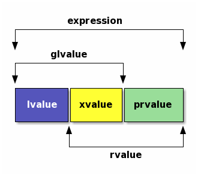

ざっくりと言えば、lvalueとは代入式の左辺になり得る式、rvalueとは代入式の左辺にはなり得ない式である。 T const&は左辺になり得ないが、lvalueである。rvalueリファレンス(T&&)もlvalueであるため、 rvalueであることとrvalueリファレンスであることとは全く異なる。

xvalueとは、多くの場合、「std::move()の呼び出し式のことである」と考えても差し支えない。

prvalueとは、いわゆるテンポラリオブジェクトのことであるため (下記のstd::string()で作られるようなオブジェクト)、名前はない。 また、アドレス演算子(&)のオペランドになれない。

```cpp
    // @@@ example/term_explanation/rvalue_lvalue_ut.cpp 8

    {
        // sを初期化するためにstd::string{}により生成されるオブジェクトはprvalue
        // sはlvalue

        auto s = std::string{};

    #if 0
        // 下記はコンパイルエラー

        auto* sp = &std::string{};
        // 下記はg++のエラーメッセージ
        // programming_convention_type.cpp|709 col 29| error: taking address of rvalue [-fpermissive]
        // ||   709 |     auto* sp = &std::string{};
    #else
        // 下記のようにすればアドレスを取得できるが、このようなことはすべきではない。
        auto&& rvalue_ref = std::string{};
        auto   sp         = &rvalue_ref;
    #endif
        static_assert(std::is_same_v<std::string*, decltype(sp)>);
    }
```

C++11でrvalueの概念の整理やstd::move()の導入が行われた目的はプログラム実行速度の向上である。

- lvalueからの代入
- rvalueからの代入
- std::move(lvalue)からの代入

の処理がどのように違うのかを見ることでrvalueの効果について説明する。

1. 下記コードにより「lvalueからの代入」を説明する。

   ```cpp
   // @@@ example/term_explanation/rvalue_lvalue_ut.cpp 35

   auto str0 = std::string{};        // str0はlvalue
   auto str1 = std::string{"hehe"};  // str1もlvalue
   str0      = str1;                 // lvalueからの代入
   ```

   - ステップ1。 str0、str1がそれぞれ初期化される (“hehe”を保持するバッファが生成され、それをstr1オブジェクトが所有する)。
   - ステップ2。 st1が所有している文字列バッファと等価のバッファが作られ (文字列バッファ用のメモリをnewし、文字列を代入)、 str0がそれを所有する。従って、“hehe”を保持するバッファが2つできる。 この代入をcopy代入と呼ぶ。

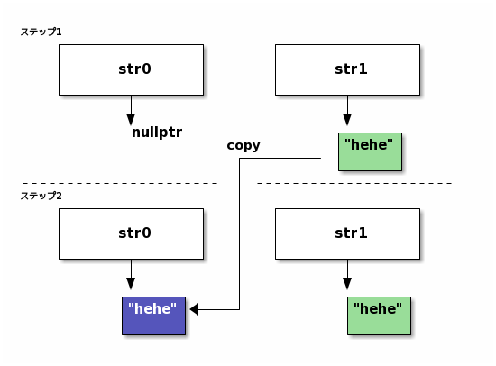

2. 下記コードにより「rvalueからの代入」を説明する。

   ```cpp
   // @@@ example/term_explanation/rvalue_lvalue_ut.cpp 46

   auto str0 = std::string{};        // str0はlvalue
   str0      = std::string{"hehe"};  // rvalueからの代入
   ```

   - ステップ1。str0、「std::string()により作られたテンポラリオブジェクト」がそれぞれ初期化される (“hehe”を保持するバッファが生成され、それをテンポラリオブジェクトが所有する)。
   - ステップ2。 “hehe”を保持する文字列バッファをもう1つ作る代わりに、 テンポラリオブジェクトが所有している文字列バッファをstr0の所有にする。 この代入をmove代入と呼ぶ。
   - ステップ3。 テンポラリオブジェクトが解体されるが、 文字列バッファはstr0の所有であるためdeleteする必要がなく、実際には何もしない。 move代入によって、文字列バッファの生成と破棄の回数がそれぞれ1回少なくなったため、 実行速度は向上する(通常、new/deleteの処理コストは高い)。

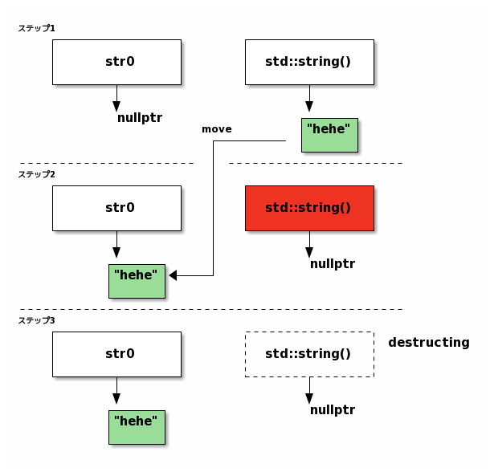

3. 下記コードにより「std::move(lvalue)からの代入」を説明する。

   ```cpp
   // @@@ example/term_explanation/rvalue_lvalue_ut.cpp 56

   auto str0 = std::string{};        // str0はlvalue
   auto str1 = std::string{"hehe"};  // str1もlvalue
   str0      = std::move(str1);      // str1はこれ以降使われないとする
   ```

   - ステップ1。「lvalueからの代入」のステップ1と同じである。
   - ステップ2。 std::move()の効果により(実際にはrvalueリファレンスへのキャストが行われるだけなので、 実行時速度に影響はない)、“hehe”を保持する文字列バッファをもう1つ作る代わりに、 str1が所有している文字列バッファをstr0の所有にする。 この代入もmove代入と呼ぶ。 この動作は「rvalueからの代入」と同じであり、同様に速度が向上するが、その副作用として、 str1.size() == 0となる。

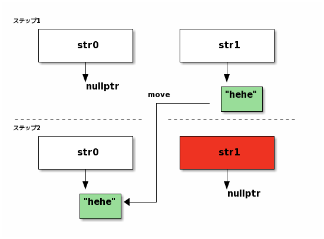

エッセンシャルタイプがTであるlvalue、xvalue、prvalueに対して (例えば、std::string const&のエッセンシャルタイプはstd::stringである)、 decltypeの算出結果は下表のようになる。

| decltype | 算出された型 |
| --- | --- |
| decltype(lvalue) | T |
| decltype((lvalue)) | T& |
| decltype(xvalue) | T&& |
| decltype((xvalue)) | T&& |
| decltype(prvalue) | T |
| decltype((prvalue)) | T |

この表の結果を使用した下記の関数型マクロ群により式を分類できる。 定義から明らかな通り、これらは [テンプレートメタプログラミング](https://ja.wikipedia.org/wiki/%E3%83%86%E3%83%B3%E3%83%97%E3%83%AC%E3%83%BC%E3%83%88%E3%83%A1%E3%82%BF%E3%83%97%E3%83%AD%E3%82%B0%E3%83%A9%E3%83%9F%E3%83%B3%E3%82%B0) に有効に活用できる。

```cpp
    // @@@ example/term_explanation/rvalue_lvalue_ut.cpp 65

    #define IS_LVALUE(EXPR_) std::is_lvalue_reference_v<decltype((EXPR_))>
    #define IS_XVALUE(EXPR_) std::is_rvalue_reference_v<decltype((EXPR_))>
    #define IS_PRVALUE(EXPR_) !std::is_reference_v<decltype((EXPR_))>
    #define IS_RVALUE(EXPR_) (IS_PRVALUE(EXPR_) || IS_XVALUE(EXPR_))

    TEST(Expression, rvalue)
    {
        auto str = std::string{};

        static_assert(IS_LVALUE(str), "EXPR_ must be lvalue");
        static_assert(!IS_RVALUE(str), "EXPR_ must NOT be rvalue");

        static_assert(IS_XVALUE(std::move(str)), "EXPR_ must be xvalue");
        static_assert(!IS_PRVALUE(std::move(str)), "EXPR_ must NOT be prvalue");

        static_assert(IS_PRVALUE(std::string{}), "EXPR_ must be prvalue");
        static_assert(IS_RVALUE(std::string{}), "EXPR_ must be rvalue");
        static_assert(!IS_LVALUE(std::string{}), "EXPR_ must NOT be lvalue");
    }
```

### lvalue

「expression」を参照せよ。

### rvalue

「expression」を参照せよ。

#### xvalue

「expression」を参照せよ。

#### prvalue

「expression」を参照せよ。

### rvalue修飾

下記GetString0()のような関数が返すオブジェクトの内部メンバに対するハンドルは、 オブジェクトのライフタイム終了後にもアクセスすることができるため、 そのハンドルを通じて、 ライフタイム終了後のオブジェクトのメンバオブジェクトにもアクセスできてしまう。

ライフタイム終了後のオブジェクトにアクセスすることは未定義動作であり、 特にそのオブジェクトがrvalueであった場合、さらにその危険性は高まる。

こういったコードに対処するためのシンタックスが、lvalue修飾、rvalue修飾である。

下記GetString1()、GetString3()、GetString4()のようにメンバ関数をlvalue修飾やrvalue修飾することで、 rvalueの内部ハンドルを返さないようにすることが可能となり、上記の危険性を緩和することができる。

```cpp
    // @@@ example/term_explanation/rvalue_lvalue_ut.cpp 91

    class C {
    public:
        explicit C(char const* str) : str_{str} {}

        // lvalue修飾なし、rvalue修飾なし
        std::string& GetString0() noexcept { return str_; }

        // lvalue修飾
        std::string const& GetString1() const& noexcept { return str_; }

        // rvalue修飾
        // *thisがrvalueの場合でのGetString1()の呼び出しは、この関数を呼び出すため、
        // class内部のハンドルを返してはならない。
        // また、それによりstd::stringを生成するため、noexcept指定してはならない。
        std::string GetString1() const&& { return str_; }

        // lvalue修飾だが、const関数はrvalueからでも呼び出せる。
        // rvalueに対しての呼び出しを禁止したい場合には、GetString4のようにする。
        std::string const& GetString2() const& noexcept { return str_; }

        // lvalue修飾
        // 非constなのでrvalueからは呼び出せない。
        std::string const& GetString3() & noexcept { return str_; }

        // lvalue修飾
        std::string const& GetString4() const& noexcept { return str_; }

        // rvalue修飾
        // rvalueからこの関数を呼び出されるとrvalueオブジェクトの内部ハンドルを返してしまい、
        // 危険なので=deleteすべき。
        std::string const& GetString4() const&& = delete;

    private:
        std::string str_;
    };
```

```cpp
    // @@@ example/term_explanation/rvalue_lvalue_ut.cpp 132

    auto        c    = C{"c0"};
    auto const& s0_0 = c.GetString0();        // OK cが解放されるまでs0_0は有効
    auto        s0_1 = C{"c1"}.GetString0();  // NG 危険なコード
    // s0_1が指すオブジェクトは、次の行で無効になる

    auto const& s1_0 = c.GetString1();        // OK GetString1()&が呼び出される
    auto const& s1_1 = C{"c1"}.GetString1();  // OK GetString1()&&が呼び出される
    // s1_0が指すrvalueはs1_0がスコープアウトするまで有効

    auto const& s2_0 = c.GetString2();        // OK GetString2()&が呼び出される
    auto const& s2_1 = C{"c1"}.GetString2();  // NG const関数はlvalue修飾しても呼び出し可能
    // s2_1が指すオブジェクトは、次の行で無効になる

    auto const& s3_0 = c.GetString3();  // OK GetString3()&が呼び出される
    // auto const& s3_1 = C{"c1"}.GetString3();  // 危険なのでコンパイルさせない

    auto const& s4_0 = c.GetString4();  // OK GetString4()&が呼び出される
    // auto const& s4_1 = C{"c1"}.GetString4();  // 危険なのでコンパイルさせない
```

### lvalue修飾

rvalue修飾を参照せよ。

### リファレンス修飾

rvalue修飾とlvalue修飾とを併せて、リファレンス修飾と呼ぶ。

### decltype

decltypeはオペランドにexpressionを取り、その型を算出する機能である。 decltype(auto)はそのオペランドの省略形である。 autoとdecltypeでは、以下に示す通りリファレンスの扱いが異なることに注意する必要がある。

```cpp
    // @@@ example/term_explanation/decltype_ut.cpp 7

    int32_t  x{3};
    int32_t& r{x};

    auto           a = r;  // aの型はint32_t
    decltype(r)    b = r;  // bの型はint32_t&
    decltype(auto) c = r;  // cの型はint32_t&   C++14からサポート
                           // decltype(auto)は、decltypeに右辺の式を与えるための構文

    // std::is_sameはオペランドの型が同じか否かを返すメタ関数
    static_assert(std::is_same_v<decltype(a), int>);
    static_assert(std::is_same_v<decltype(b), int&>);
    static_assert(std::is_same_v<decltype(c), int&>);
```

decltypeは、テンプレートプログラミングに多用されるが、 クロージャ型(「ラムダ式」参照) のような記述不可能な型をオブジェクトから算出できるため、 下記例のような場合にも有用である。

```cpp
    // @@@ example/term_explanation/decltype_ut.cpp 26

    //  本来ならばA::dataは、
    //      * A::Aでメモリ割り当て
    //      * A::~Aでメモリ解放
    //  すべきだが、何らかの理由でそれが出来ないとする
    struct A {
        size_t   len;
        uint8_t* data;
    };

    void do_something(size_t len)
    {
        auto deallocate = [](A* p) {
            delete[](p->data);
            delete p;
        };

        auto a_ptr = std::unique_ptr<A, decltype(deallocate)>{new A, deallocate};

        a_ptr->len  = len;
        a_ptr->data = new uint8_t[10];

        ...
        // do something for a_ptr
        ...

        // a_ptrによるメモリの自動解放
    }
```

## リファレンス

ここでは、C++11から導入された

- ユニバーサルリファレンス
- リファレンスcollapsing

について解説する。

### ユニバーサルリファレンス

関数テンプレートの型パラメータや型推論autoに&&をつけて宣言された変数を、 ユニバーサルリファレンスと呼ぶ(C++17から「forwardingリファレンス」という正式名称が与えられた)。 ユニバーサルリファレンスは一見rvalueリファレンスのように見えるが、 下記に示す通り、lvalueにもrvalueにもバインドできる。

```cpp
    // @@@ example/term_explanation/universal_ref_ut.cpp 8

    template <typename T>
    void f(T&& t) noexcept  // tはユニバーサルリファレンス
    {
        ...
    }

    template <typename T>
    void g(std::vector<T>&& t) noexcept  // tはrvalueリファレンス
    {
        ...
    }
```

```cpp
    // @@@ example/term_explanation/universal_ref_ut.cpp 29

    auto       vec  = std::vector<std::string>{"lvalue"};   // vecはlvalue
    auto const cvec = std::vector<std::string>{"clvalue"};  // cvecはconstなlvalue

    f(vec);                                 // 引数はlvalue
    f(cvec);                                // 引数はconstなlvalue
    f(std::vector<std::string>{"rvalue"});  // 引数はrvalue

    // g(vec);  // 引数がlvalueなのでコンパイルエラー
    // g(cvec); // 引数がconst lvalueなのでコンパイルエラー
    g(std::vector<std::string>{"rvalue"});  // 引数はrvalue
```

下記のコードはジェネリックラムダ(「ラムダ式」参照) の引数をユニバーサルリファレンスにした例である。

```cpp
    // @@@ example/term_explanation/universal_ref_ut.cpp 47

    // sはユニバーサルリファレンス
    auto value_type = [](auto&& s) noexcept {
        if (std::is_same_v<std::string&, decltype(s)>) {
            return 0;
        }
        if (std::is_same_v<std::string const&, decltype(s)>) {
            return 1;
        }
        if (std::is_same_v<std::string&&, decltype(s)>) {
            return 2;
        }
        return 3;
    };

    auto       str  = std::string{"lvalue"};
    auto const cstr = std::string{"const lvalue"};

    ASSERT_EQ(0, value_type(str));
    ASSERT_EQ(1, value_type(cstr));
    ASSERT_EQ(2, value_type(std::string{"rvalue"}));
```

通常、ユニバーサルリファレンスはstd::forwardと組み合わせて使用される。

### forwardingリファレンス

「ユニバーサルリファレンス」を参照せよ。

### perfect forwarding

perfect forwarding とは、引数のrvalue性や lvalue性を損失することなく、 その引数を別の関数に転送する技術のことを指す。 通常は、ユニバーサルリファレンスである関数の仮引数をstd::forwardを用いて、 他の関数に渡すことで実現される。

### リファレンスcollapsing

Tを任意の型とし、TRを下記のように宣言した場合、

```cpp
    using TR = T&;
```

下記のようなコードは、C++03ではコンパイルエラーとなったが、 C++11からはエラーとならず、TRRはT&となる。

```cpp
    using TRR = TR&;
```

2つの&を1つに折り畳む、このような機能をリファレンスcollapsingと呼ぶ。

下記はTをintとした場合のリファレンスcollapsingの動きを示している。

```cpp
    // @@@ example/term_explanation/ref_collapsing_ut.cpp 7

    int i;

    using IR  = int&;
    using IRR = IR&;  // IRRはint& &となり、int&に変換される

    IR  ir  = i;
    IRR irr = ir;

    static_assert(std::is_same_v<int&, decltype(ir)>);   // lvalueリファレンス
    static_assert(std::is_same_v<int&, decltype(irr)>);  // lvalueリファレンス
```

リファレンスcollapsingは、型エイリアス、型であるテンプレートパラメータ、decltypeに対して行われる。 詳細な変換則は、下記のようになる。

```
    T& &   -> T&
    T& &&  -> T&
    T&& &  -> T&
    T&& && -> T&&
```

下記のようなクラステンプレートを定義した場合、

```cpp
    // @@@ example/term_explanation/ref_collapsing_ut.cpp 26

    template <typename T>
    struct Ref {
        T&  t;
        T&& u;
    };
```

下記のコードにより、テンプレートパラメータに対するこの変換則を確かめることができる。

```cpp
    // @@@ example/term_explanation/ref_collapsing_ut.cpp 38

    static_assert(std::is_same_v<int&, decltype(Ref<int>::t)>);    // lvalueリファレンス
    static_assert(std::is_same_v<int&&, decltype(Ref<int>::u)>);   // rvalueリファレンス

    static_assert(std::is_same_v<int&, decltype(Ref<int&>::t)>);   // lvalueリファレンス
    static_assert(std::is_same_v<int&, decltype(Ref<int&>::u)>);   // lvalueリファレンス

    static_assert(std::is_same_v<int&, decltype(Ref<int&&>::t)>);  // lvalueリファレンス
    static_assert(std::is_same_v<int&&, decltype(Ref<int&&>::u)>); // rvalueリファレンス
```

この機能がないC++03では、

```cpp
    // @@@ example/term_explanation/ref_collapsing_ut.cpp 52

    template <typename T>
    struct AddRef {
        using type = T&;
    };
```

ようなクラステンプレートに下記コードのようにリファレンス型を渡すとコンパイルエラーとなる。

```cpp
    // @@@ example/term_explanation/ref_collapsing_ut.cpp 69

    static_assert(std::is_same_v<int&, AddRef<int&>::type>);
```

この問題を回避するためには下記のようなテンプレートの特殊化が必要になる。

```cpp
    // @@@ example/term_explanation/ref_collapsing_ut.cpp 59

    template <typename T>
    struct AddRef<T&> {
        using type = T&;
    };
```

上記したようなクラステンプレートでのメンバエイリアスの宣言は、 [テンプレートメタプログラミング](https://ja.wikipedia.org/wiki/%E3%83%86%E3%83%B3%E3%83%97%E3%83%AC%E3%83%BC%E3%83%88%E3%83%A1%E3%82%BF%E3%83%97%E3%83%AD%E3%82%B0%E3%83%A9%E3%83%9F%E3%83%B3%E3%82%B0) で頻繁に使用されるため、 このようなテンプレートの特殊化を不要にするリファレンスcollapsingは、 有用な機能拡張であると言える。

### danglingリファレンス

Dangling リファレンスとは、破棄後のオブジェクトを指しているリファレンスを指す。 このようなリファレンスにアクセスすると、未定義動作動作に繋がるに繋がる。

```cpp
    // @@@ example/term_explanation/dangling_ut.cpp 9

    bool X_destructed;
    class X {
    public:
        X() { X_destructed = false; }
        ~X() { X_destructed = true; }
    };

    bool A_destructed;
    class A {
    public:
        A() { A_destructed = false; }
        ~A() { A_destructed = true; }

        X const& GetX() const noexcept { return x_; }

    private:
        X x_;
    };

    // @@@ example/term_explanation/dangling_ut.cpp 34

    auto a = A{};

    auto const& x_safe = a.GetX();  // x_safeはダングリングリファレンスではない
    ASSERT_FALSE(A_destructed || X_destructed);

    auto const& x_dangling = A{}.GetX();  // 次の行でxが指すオブジェクトは解放される
    // この行ではxはdangngling リファレンスになる。
    ASSERT_TRUE(A_destructed && X_destructed);

    auto const* x_ptr_dangling = &A{}.GetX();  // 次の行でxが指すオブジェクトは解放される
    // この行ではxはdangngling ポインタになる。
    ASSERT_TRUE(A_destructed && X_destructed);
```

### danglingポインタ

danglingポインタとは、danglingリファレンスと同じような状態になったポインタを指す。

## エクセプション安全性の保証

関数のエクセプション発生時の安全性の保証には以下の3つのレベルが規定されている。

### no-fail保証

「no-fail保証」を満たす関数はエクセプションをthrowしない。

### 強い保証

「強い保証」を満たす関数は、この関数がエクセプションによりスコープから外れた場合でも、 この関数が呼ばれなかった状態と同じ(プログラムカウンタ以外の状態は同じ)であることを保証する。 従って、この関数呼び出しは成功したか、完全な無効だったかのどちらかになる。

### 基本保証

「基本保障」を満たす関数は、この関数がエクセプションによりスコープから外れた場合でも、 メモリ等のリソースリークは起こさず、 オブジェクトは(変更されたかもしれないが)引き続き使えることを保証する。

## シンタックス、セマンティクス

直訳すれば、シンタックスとは構文論のことであり、セマンティクスとは意味論のことである。 この二つの概念の違いをはっきりと際立たせる有名な文を例示する。

```
    Colorless green ideas sleep furiously(直訳:無色の緑の考えが猛烈に眠る)
```

この文は構文的には正しい(シンタックスは問題ない)が、 意味不明である(セマンティクスは誤り)。

C++プログラミングにおいては、コンパイルできることがシンタックス的な正しさであり、例えば

- クラスや関数がその名前から想起できる責務を持っている
  - 「単一責任の原則(SRP)」を満たしている
  - Accessorを実装する関数の名前は、GetXxxやSetXxxになっている
  - コンテナクラスのメンバ関数beginやendは、 そのクラスが保持する値集合の先頭や最後尾の次を指すイテレータを返す
  - 等
- 「等価性のセマンティクス」を守ってる
- 「copyセマンティクス」を守ってる
- 「moveセマンティクス」を守っている

等がセマンティクス的な正しさである。

セマンティクス的に正しいソースコードは読みやすく、保守性、拡張性に優れている。

### 等価性のセマンティクス

純粋数学での実数の等号(=)は、任意の実数x、y、zに対して、

| 律 | 意味 |
| --- | --- |
| 反射律 | x = x |
| 対称律 | x = yならばy = x |
| 推移律 | x = y且つy = zならばx = z |

を満たしている。x = yが成立する場合、「xはyと等しい」もしくは「xはyと同一」であると言う。

C++における組み込みの==も純粋数学の等号と同じ性質を満たしている。 下記のコードは、その性質を表している。

```cpp
    // @@@ example/term_explanation/semantics_ut.cpp 12

    auto  a = 0;
    auto& b = a;

    ASSERT_TRUE(a == b);
    ASSERT_TRUE(&a == &b);  // aとbは同一
```

しかし、下記のコード内のa、bは同じ値を持つが、 アドレスが異なるため同一のオブジェクトではないにもかかわらず、組み込みの==の値はtrueとなる。

```cpp
    // @@@ example/term_explanation/semantics_ut.cpp 22

    auto a = 0;
    auto b = 0;

    ASSERT_TRUE(a == b);
    ASSERT_FALSE(&a == &b);  // aとbは同一ではない
```

このような場合、aとbは等価であるという。同一ならば等価であるが、等価であっても同一とは限らない。

ポインタや配列をオペランドとする場合を除き、C++における組み込みの==は、 数学の等号とは違い、等価を表していると考えられるが、 上記した3つの律を守っている。従ってオーバーロードoperator==も同じ性質を守る必要がある。

組み込みの==やオーバーロードoperator==のこのような性質をここでは「等価性のセマンティクス」と呼ぶ。

クラスAを下記のように定義し、

```cpp
    // @@@ example/term_explanation/semantics_ut.cpp 33

    class A {
    public:
        explicit A(int num, char const* name) noexcept : num_{num}, name_{name} {}

        int         GetNum() const noexcept { return num_; }
        char const* GetName() const noexcept { return name_; }

    private:
        int const   num_;
        char const* name_;
    };
```

そのoperator==を下記のように定義した場合、

```cpp
    // @@@ example/term_explanation/semantics_ut.cpp 50

    inline bool operator==(A const& lhs, A const& rhs) noexcept
    {
        return lhs.GetNum() == rhs.GetNum() && lhs.GetName() == rhs.GetName();
    }
```

単体テストは下記のように書けるだろう。

```cpp
    // @@@ example/term_explanation/semantics_ut.cpp 61

    auto a0 = A{0, "a"};
    auto a1 = A{0, "a"};

    ASSERT_TRUE(a0 == a1);
```

これは、一応パスするが(処理系定義の動作を前提とするため、必ず動作する保証はない)、 下記のようにすると、パスしなくなる。

```cpp
    // @@@ example/term_explanation/semantics_ut.cpp 71

    char a0_name[] = "a";
    auto a0        = A{0, a0_name};

    char a1_name[] = "a";
    auto a1        = A{0, a1_name};

    ASSERT_TRUE(a0 == a1);  // テストが失敗する
```

一般にポインタの等価性は、その値の同一性ではなく、 そのポインタが指すオブジェクトの等価性で判断されるべきであるが、 先に示したoperator==はその考慮をしていないため、このような結果になった。

次に、これを修正した例を示す。

```cpp
    // @@@ example/term_explanation/semantics_ut.cpp 90

    inline bool operator==(A const& lhs, A const& rhs) noexcept
    {
        return lhs.GetNum() == rhs.GetNum()
               && std::string_view{lhs.GetName()} == std::string_view{rhs.GetName()};
    }
```

ポインタをメンバに持つクラスのoperator==については、上記したような処理が必要となる。

次に示す例は、基底クラスBaseとそのoperator==である。

```cpp
    // @@@ example/term_explanation/semantics_ut.cpp 113

    class Base {
    public:
        explicit Base(int b) noexcept : b_{b} {}
        virtual ~Base() = default;
        int GetB() const noexcept { return b_; }

    private:
        int b_;
    };

    inline bool operator==(Base const& lhs, Base const& rhs) noexcept
    {
        return lhs.GetB() == rhs.GetB();
    }
```

次の単体テストが示す通り、これ自体には問題がないように見える。

```cpp
    // @@@ example/term_explanation/semantics_ut.cpp 133

    auto b0 = Base{0};
    auto b1 = Base{0};
    auto b2 = Base{1};

    ASSERT_TRUE(b0 == b0);
    ASSERT_TRUE(b0 == b1);
    ASSERT_FALSE(b0 == b2);
```

しかし、Baseから派生したクラスDerivedを

```cpp
    // @@@ example/term_explanation/semantics_ut.cpp 145

    class Derived : public Base {
    public:
        explicit Derived(int d) noexcept : Base{0}, d_{d} {}
        int GetD() const noexcept { return d_; }

    private:
        int d_;
    };
```

のように定義すると、下記の単体テストで示す通り、等価性のセマンティクスが破壊される。

```cpp
    // @@@ example/term_explanation/semantics_ut.cpp 159

    {
        auto b = Base{0};
        auto d = Derived{1};

        ASSERT_TRUE(b == d);  // NG bとdは明らかに等価でない
    }
    {
        auto d0 = Derived{0};
        auto d1 = Derived{1};

        ASSERT_TRUE(d0 == d1);  // NG d0とd1は明らかに等価ではない
    }
```

Derived用のoperator==を

```cpp
    // @@@ example/term_explanation/semantics_ut.cpp 176

    bool operator==(Derived const& lhs, Derived const& rhs) noexcept
    {
        return lhs.GetB() == rhs.GetB() && lhs.GetD() == rhs.GetD();
    }
```

と定義しても、下記に示す通り部分的な効果しかない。

```cpp
    // @@@ example/term_explanation/semantics_ut.cpp 186

    auto d0 = Derived{0};
    auto d1 = Derived{1};

    ASSERT_FALSE(d0 == d1);  // OK operator==(Derived const&, Derived const&)の効果で正しい判定

    Base& d0_b_ref = d0;

    ASSERT_TRUE(d0_b_ref == d1);  // NG d0_b_refの実態はd0なのでd1と等価でない
```

この問題は、RTTIを使った下記のようなコードで対処できる。

```cpp
    // @@@ example/term_explanation/semantics_ut.cpp 202

    class Base {
    public:
        explicit Base(int b) noexcept : b_{b} {}
        virtual ~Base() = default;
        int GetB() const noexcept { return b_; }

    protected:
        virtual bool is_equal(Base const& rhs) const noexcept { return b_ == rhs.b_; }

    private:
        int b_;

        friend inline bool operator==(Base const& lhs, Base const& rhs) noexcept
        {
            if (typeid(lhs) != typeid(rhs)) {
                return false;
            }

            return lhs.is_equal(rhs);
        }
    };

    class Derived : public Base {
    public:
        explicit Derived(int d) : Base{0}, d_{d} {}
        int GetD() const noexcept { return d_; }

    protected:
        virtual bool is_equal(Base const& rhs) const noexcept
        {
            // operator==によりrhsの型はDerivedであるため、下記のキャストは安全
            auto const& rhs_d = static_cast<Derived const&>(rhs);

            return Base::is_equal(rhs) && d_ == rhs_d.d_;
        }

    private:
        int d_;
    };
```

下記に示す通り、このコードは、 オープン・クローズドの原則(OCP)にも対応した柔軟な構造を実現している。

```cpp
    // @@@ example/term_explanation/semantics_ut.cpp 269

    class DerivedDerived : public Derived {
    public:
        explicit DerivedDerived(int dd) noexcept : Derived{0}, dd_{dd} {}
        int GetDD() const noexcept { return dd_; }

    protected:
        virtual bool is_equal(Base const& rhs) const noexcept
        {
            // operator==によりrhsの型はDerivedDerivedであるため、下記のキャストは安全
            auto const& rhs_d = static_cast<DerivedDerived const&>(rhs);

            return Derived::is_equal(rhs) && dd_ == rhs_d.dd_;
        }

    private:
        int dd_;
    };
```

前例では「両辺の型が等しいこと」が「等価であること」の必要条件となるが、 この要件が、すべてのoperator==に求められるわけではない。

次に示すのは、一見すると両辺の型が違うにもかかわらず、 等価性のセマンティクスを満たしている例である。

```cpp
    // @@@ example/term_explanation/semantics_ut.cpp 319

    auto abc = std::string{"abc"};

    ASSERT_TRUE("abc" == abc);
    ASSERT_TRUE(abc == "abc");
```

これは、文字列リテラルを第1引数に取るstd::stringのコンストラクタが非explicitであることによって、 文字列リテラルからstd::stringへの暗黙の型変換が起こるために成立する (「非explitなコンストラクタによる暗黙の型変換」参照)。

以上で見てきたように、等価性のセマンティクスを守ったoperator==の実装には多くの観点が必要になる。

### copyセマンティクス

copyセマンティクスとは以下を満たすようなセマンティクスである。

- a = bが行われた後に、aとbが等価である。
- a = bが行われた前後でbの値が変わっていない。

従って、これらのオブジェクトに対して等価性のセマンティクス を満たすoperator==が定義されている場合、 以下を満たすようなセマンティクスであると言い換えることができる。

- a = bが行われた後に、a == bがtrueになる。
- b == b_preがtrueの時に、a = bが行われた後でもb == b_preがtrueとなる。

下記に示す通り、std::stringはcopyセマンティクスを満たしている。

```cpp
    // @@@ example/term_explanation/semantics_ut.cpp 333

    auto c_str = "string";
    auto str   = std::string{};

    str = c_str;
    ASSERT_TRUE(c_str == str);      // = 後には == が成立している
    ASSERT_STREQ("string", c_str);  // c_strの値は変わっていない
```

一方で、std::auto_ptrはcopyセマンティクスを満たしていない。

```cpp
    // @@@ example/term_explanation/semantics_ut.cpp 346

    std::auto_ptr<std::string> str0{new std::string{"string"}};
    std::auto_ptr<std::string> str0_pre{new std::string{"string"}};

    ASSERT_TRUE(*str0 == *str0_pre);  // 前提は成立

    std::auto_ptr<std::string> str1;

    str1 = str0;

    // ASSERT_TRUE(*str0 == *str0_pre);  // これをするとクラッシュする
    ASSERT_TRUE(str0.get() == nullptr);  // str0の値がoperator ==で変わってしまった

    ASSERT_TRUE(*str1 == *str0_pre);  // これは成立
```

この仕様は極めて不自然であり、std::auto_ptrはC++11で非推奨となり、C++17で規格から排除された。

下記の単体テストから明らかな通り、 「等価性のセマンティクス」で示した最後の例も、copyセマンティクスを満たしていない。

```cpp
    // @@@ example/term_explanation/semantics_ut.cpp 366

    auto b = Base{1};
    auto d = Derived{1};

    b = d;  // スライシングが起こる

    ASSERT_FALSE(b == d);  // copyセマンティクスを満たしていない
```

原因は、copy代入でスライシングが起こるためである。

### moveセマンティクス

moveセマンティクスとは以下を満たすようなセマンティクスである(operator==が定義されていると前提)。

- copy代入の実行コスト >= move代入の実行コスト
- a == bがtrueの時に、c = std::move(a)が行われた場合、
  - b == cがtrueになる。
  - a == cはtrueにならなくても良い(aはmove代入により破壊されるかもしれない)。

  必須ではないが、「aがポインタ等のリソースを保有している場合、move代入後には、 そのリソースはcに移動している」ことが一般的である(「rvalue」参照)。
- no-fail保証をする(noexceptと宣言し、エクセプションをthrowしない)。

moveセマンティクスはcopy代入後に使用されなくなるオブジェクト(主にrvalue) からのcopy代入の実行コストを下げるために導入されたため、 下記のようなコードは推奨されない。

```cpp
    // @@@ example/term_explanation/semantics_ut.cpp 381

    class NotRecommended {
    public:
        NotRecommended(char const* name) : name_{name} {}
        std::string const& Name() const noexcept { return name_; }

        NotRecommended& operator=(NotRecommended&& rhs)  // move代入、非no-fail保証
        {
            name_ = rhs.name_;  // rhs.name_からname_へのcopy代入。パフォーマンス問題になるかも。
            return *this;
        }

    private:
        std::string name_;
    };

    bool operator==(NotRecommended const& lhs, NotRecommended const& rhs) noexcept
    {
        return lhs.Name() == rhs.Name();
    }

    TEST(Semantics, move1)
    {
        auto a = NotRecommended{"a"};
        auto b = NotRecommended{"a"};

        ASSERT_EQ("a", a.Name());
        ASSERT_TRUE(a == b);

        auto c = NotRecommended{"c"};
        ASSERT_EQ("c", c.Name());

        c = std::move(a);
        ASSERT_TRUE(b == c);  // 一応、moveセマンティクスは守っているが・・・
    }
```

下記のコードのようにメンバの代入もできる限りmove代入を使うことで、 パフォーマンスの良い代入ができる。

```cpp
    // @@@ example/term_explanation/semantics_ut.cpp 419

    class Recommended {
    public:
        Recommended(char const* name) : name_{name} {}
        std::string const& Name() const noexcept { return name_; }

        Recommended& operator=(Recommended&& rhs) noexcept  // move代入、no-fail保証
        {
            name_ = std::move(rhs.name_);  // rhs.name_からname_へのmove代入
            return *this;
        }

    private:
        std::string name_;
    };

    bool operator==(Recommended const& lhs, Recommended const& rhs) noexcept
    {
        return lhs.Name() == rhs.Name();
    }

    TEST(Semantics, move2)
    {
        auto a = Recommended{"a"};
        auto b = Recommended{"a"};

        ASSERT_EQ("a", a.Name());
        ASSERT_TRUE(a == b);

        auto c = Recommended{"c"};
        ASSERT_EQ("c", c.Name());

        c = std::move(a);     // これ以降aは使ってはならない
        ASSERT_TRUE(b == c);  // moveセマンティクスを正しく守っている
    }
```

## C++コンパイラ

本ドキュメントで使用するg++/clang++のバージョンは以下のとおりである。

### g++

```
    g++ (Ubuntu 11.3.0-1ubuntu1~22.04) 11.3.0
    Copyright (C) 2021 Free Software Foundation, Inc.
    This is free software; see the source for copying conditions.  There is NO
    warranty; not even for MERCHANTABILITY or FITNESS FOR A PARTICULAR PURPOSE.
```

### clang++

```
    Ubuntu clang version 14.0.0-1ubuntu1
    Target: x86_64-pc-linux-gnu
    Thread model: posix
    InstalledDir: /usr/bin
```

## C++その他

### オーバーライドとオーバーロードの違い

下記例では、Base::g()がオーバーロードで、Derived::f()がオーバーライドである (Derived::g()はオーバーロードでもオーバーライドでもない(「name-hiding」参照))。

```cpp
    // @@@ example/term_explanation/override_overload_ut.cpp 5

    class Base {
    public:
        virtual ~Base() = default;
        virtual std::string f() { return "Base::f"; }
        std::string         g() { return "Base::g"; }

        // g()のオーバーロード
        std::string g(int) { return "Base::g(int)"; }
    };

    class Derived : public Base {
    public:
        // Base::fのオーバーライド
        virtual std::string f() override { return "Derived::f"; }

        // Base::gのname-hiding
        std::string g() { return "Derived::g"; }
    };
```

下記図の通り、

- BaseのインスタンスはBase用のvtblへのポインタを内部に持ち、 そのvtblでBase::f()のアドレスを保持する。
- DerivedのインスタンスはDerived用のvtblへのポインタを内部に持ち、 そのvtblでDerived::f()のアドレスを保持する。
- Base::g()、Base::g(int)、 Derived::g()のアドレスはBaseやDerivedのインスタンスから辿ることはできない。

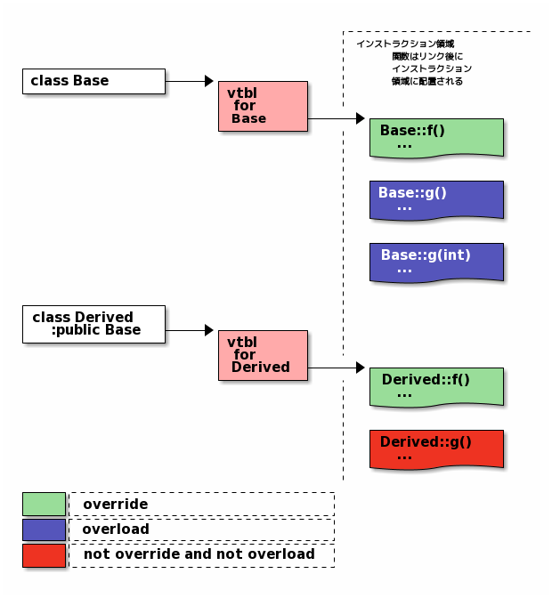

vtblとは仮想関数テーブルとも呼ばれる、仮想関数ポインタを保持するための上記のようなテーブルである (「クラスのレイアウト」参照)。

Base::f()、Derived::f()の呼び出し選択は、オブジェクトの表層の型ではなく、実際の型により決定される。 Base::g()、Derived::g()の呼び出し選択は、オブジェクトの表層の型により決定される。

```cpp
    // @@@ example/term_explanation/override_overload_ut.cpp 29

    auto  ret   = std::string{};
    auto  b     = Base{};
    auto  d     = Derived{};
    Base& d_ref = d;

    ret = b.f();  // Base::f()呼び出し
    ASSERT_EQ("Base::f", ret);

    ret = d.f();  // Derived::f()呼び出し
    ASSERT_EQ("Derived::f", ret);

    ret = b.g();  // Base::g()呼び出し
    ASSERT_EQ("Base::g", ret);

    ret = d.g();  // Derived::g()呼び出し
    ASSERT_EQ("Derived::g", ret);
    // ret = d.g(int{});   // Derived::gによって、Base::gが隠されるのでコンパイルエラー

    ret = d_ref.f();  // Base::fはDerived::fによってオーバーライドされたので、Derived::f()呼び出し
    ASSERT_EQ("Derived::f", ret);

    ret = d_ref.g();  // d_refの表層型はBaseなので、Base::g()呼び出し
    ASSERT_EQ("Base::g", ret);

    ret = d_ref.g(int{});  // d_refの表層型はBaseなので、Base::g(int)呼び出し
    ASSERT_EQ("Base::g(int)", ret);
```

上記のメンバ関数呼び出し

```cpp
    d_ref.f()
```

がどのように解釈され、Derived::f()が選択されるかを以下に疑似コードで例示する。

```cpp
    vtbl = d_ref.vtbl             // d_refの実態はDerivedなのでvtblはDerivedのvtbl

    member_func = vtbl->f         // vtbl->fはDerived::f()のアドレス

    (d_ref.*member_func)(&d_ref)  // member_func()の呼び出し
```

このようなメカニズムにより仮想関数呼び出しが行われる。

### 実引数/仮引数

引数(もしくは実引数、argument)、仮引数(parameter)とは下記のように定義される。

```cpp
    // @@@ example/term_explanation/argument.cpp 2

    int f0(int a, int& b) noexcept  // a, bは仮引数
    {
        ...
    }

    void f1() noexcept
    {
        ...

        f0(x, y);  // x, yは実引数
    }
```

### 範囲for文

範囲for文は下記例のコメントで示されたようなfor文であり、 begin()、end()によって表される範囲内のすべての要素に対して付属するブロックの処理を行う。

```cpp
    // @@@ example/term_explanation/range_for_ut.cpp 9

    auto list = std::list{1, 2, 3};

    for (auto const a : list) {  // 範囲for文
        std::cout << a << std::endl;
    }

    // 上記for文は下記for文のシンタックスシュガー
    for (std::list<int32_t>::iterator it = std::begin(list); it != std::end(list); ++it) {
        std::cout << *it << std::endl;
    }
```

```cpp
    // @@@ example/term_explanation/range_for_ut.cpp 25

    int32_t array[3]{1, 2, 3};

    for (auto const a : array) {  // 範囲for文
        std::cout << a << std::endl;
    }

    // 上記for文は下記for文のシンタックスシュガー
    for (int32_t* it = std::begin(array); it != std::end(array); ++it) {
        std::cout << *it << std::endl;
    }
```

### ラムダ式

ラムダ式に関する言葉の定義と例を示す。

- ラムダ式とは、その場で関数オブジェクトを定義する式。
- クロージャ(オブジェクト)とは、ラムダ式から生成された関数オブジェクト。
- クロージャ型とは、クロージャオブジェクトの型。
- キャプチャとは、ラムダ式外部の変数をラムダ式内にコピーかリファレンスとして定義する機能。
- ラムダ式からキャプチャできるのは、ラムダ式から可視である自動変数と仮引数(thisを含む)。
- ジェネリックラムダとは、C++11のラムダ式を拡張して、 パラメータにautoを使用(型推測)できるようにした機能。

```cpp
    // @@@ example/term_explanation/lambda.cpp 10

    auto a = 0;

    // closureがクロージャ。それを初期化する式がラムダ式
    // [a = a]がキャプチャ
    // [a = a]内の右辺aは上記で定義されたa
    // [a = a]内の左辺aは右辺aで初期化された変数。ラムダ式内で使用されるaは左辺a。
    auto closure = [a = a](int32_t b) noexcept { return a + b; };

    auto ret = closure(3);  // クロージャの実行

    // g_closureはジェネリックラムダ
    auto g_closure = [](auto t0, auto t1) { return t0 + t1; };

    auto i = g_closure(1, 2);                                // t0、t1はint
    auto s = g_closure(std::string{"1"}, std::string{"2"});  // t0、t1はstd::string
```

### ジェネリックラムダ

ジェネリックラムダとは、C++11のラムダ式のパラメータの型にautoを指定できるようにした機能で、 C++14で導入された。

この機能により関数の中で関数テンプレートと同等のものが定義できるようになった。

ジェネリックラムダで定義されたクロージャは、通常のラムダと同様にオブジェクトであるため、 下記のように使用することもできる便利な記法である。

```cpp
    // @@@ example/term_explanation/generic_lambda_ut.cpp 4

    template <typename PUTTO>
    void f(PUTTO&& p)
    {
        p(1);
        p(2.71);
        p("str");
    }

    TEST(Template, generic_lambda)
    {
        std::ostringstream oss;

        f([&oss](auto const& elem) { oss << elem << std::endl; });

        ASSERT_EQ("1\n2.71\nstr\n", oss.str());
    }
```

なお、上記のジェネリックラムダは下記クラスのインスタンスの動きと同じである。

```cpp
    // @@@ example/term_explanation/generic_lambda_ut.cpp 23

    class Closure {
    public:
        Closure(std::ostream& os) : os_(os) {}

        template <typename T>
        void operator()(T&& t)
        {
            os_ << t << std::endl;
        }

    private:
        std::ostream& os_;
    };

    TEST(Template, generic_lambda_like)
    {
        std::ostringstream oss;

        Closure closure(oss);
        f(closure);

        ASSERT_EQ("1\n2.71\nstr\n", oss.str());
    }
```

### 関数tryブロック

関数tryブロックとはtry-catchを本体とした下記のような関数のブロックを指す。

```cpp
    // @@@ example/term_explanation/func_try_block.cpp 8

    void function_try_block()
    try {  // 関数tryブロック
        // 何らかの処理
        ...
    }
    catch (std::length_error const& e) {  // 関数tryブロックのエクセプションハンドラ
        ...
    }
    catch (std::logic_error const& e) {  // 関数tryブロックのエクセプションハンドラ
        ...
    }
```

### 単純代入

代入は下記のように分類される。

- 単純代入(=)
- 複合代入(+=，++ 等)

### ill-formed

[標準規格と処理系](https://cpprefjp.github.io/implementation-compliance.html)に詳しい解説があるが、

- well-formed(適格)とはプログラムが全ての構文規則・診断対象の意味規則・ 単一定義規則を満たすことである。
- ill-formed(不適格)とはプログラムが適格でないことである。

プログラムがwell-formedになった場合、そのプログラムはコンパイルできる。 プログラムがill-formedになった場合、通常はコンパイルエラーになるが、 対象がテンプレートの場合、事情は少々異なり、SFINAEによりコンパイルできることもある。

### well-formed

「ill-formed」を参照せよ。

### one-definition rule

「ODR」を参照せよ。

### ODR

ODRとは、One Definition Ruleの略語であり、下記のようなことを定めている。

- どの翻訳単位でも、テンプレート、型、関数、またはオブジェクトは、複数の定義を持つことができない。
- プログラム全体で、オブジェクトまたは非インライン関数は複数の定義を持つことはできない。
- 型、テンプレート、外部インライン関数等、いくつかのものは複数の翻訳単位で定義することができる。

より詳しい内容がが知りたい場合は、 https://en.cppreference.com/w/cpp/language/definition が参考になる。

### RVO(Return Value Optimization)

関数の戻り値がオブジェクトである場合、 戻り値オブジェクトは、その関数の呼び出し元のオブジェクトにコピーされた後、すぐに破棄される。 この「オブジェクトをコピーして、その後すぐにそのオブジェクトを破棄する」動作は、 「関数の戻り値オブジェクトをそのままその関数の呼び出し元で使用する」ことで効率的になる。 RVOとはこのような最適化を指す。

なお、このような最適化は、 [C++17から規格化](https://cpprefjp.github.io/lang/cpp17/guaranteed_copy_elision.html)された。

### SSO(Small String Optimization)

一般にstd::stringで文字列を保持する場合、newしたメモリが使用される。 64ビット環境であれば、newしたメモリのアドレスを保持する領域は8バイトになる。 std::stringで保持する文字列が終端の’\0’も含め8バイト以下である場合、 アドレスを保持する領域をその文字列の格納に使用すれば、newする必要がない(当然deleteも不要)。 こうすることで、短い文字列を保持するstd::stringオブジェクトは効率的に動作できる。

SOOとはこのような最適化を指す。

### Most Vexing Parse

Most Vexing Parse(最も困惑させる構文解析)とは、C++の文法に関連する問題で、 Scott Meyersが彼の著書”Effective STL”の中でこの現象に名前をつけたことに由来する。

この問題はC++の文法が関数の宣言と変数の定義とを曖昧に扱うことによって生じる。 特にオブジェクトの初期化の文脈で発生し、意図に反して、その行は関数宣言になってしまう。

```cpp
    // @@@ example/term_explanation/most_vexing_parse_ut.cpp 6

    class Vexing {
    public:
        Vexing(int) {}
    };

    // @@@ example/term_explanation/most_vexing_parse_ut.cpp 19

    Vexing obj1();        // はローカルオブジェクトobj1の宣言ではない
    Vexing obj2(Vexing);  // ローカルオブジェクトobj2の宣言ではない

    ASSERT_EQ("Vexing ()", Nstd::Type2Str<decltype(obj1)>());
    ASSERT_EQ("Vexing (Vexing)", Nstd::Type2Str<decltype(obj2)>());
    // 上記単体テストが示すように、
    // * obj1はVexingを返す関数
    // * obj2はVexingを引数に取りVexingを返す関数
    // となる。
```

初期化子リストコンストラクタの呼び出しでオブジェクトの初期化を行うことで、 このような問題を回避できる。

### RTTI

RTTI(Run-time Type Information)とは、プログラム実行中のオブジェクトの型を導出するための機能であり、 具体的には下記の3つの要素を指す。

- dynamic_cast
- typeid
- std::type_info

下記のようなポリモーフィックな(virtual関数を持った)クラスに対しては、

```cpp
    // @@@ example/term_explanation/rtti_ut.cpp 7

    class Polymorphic_Base {  // ポリモーフィックな基底クラス
    public:
        virtual ~Polymorphic_Base() = default;
    };

    class Polymorphic_Derived : public Polymorphic_Base {  // ポリモーフィックな派生クラス
    };
```

dynamic_cast、typeidやその戻り値であるstd::type_infoは、下記のように振舞う。

```cpp
    // @@@ example/term_explanation/rtti_ut.cpp 21

    auto b = Polymorphic_Base{};
    auto d = Polymorphic_Derived{};

    Polymorphic_Base& b_ref_d = d;
    Polymorphic_Base& b_ref_b = b;

    // std::type_infoの比較
    ASSERT_EQ(typeid(b_ref_d), typeid(d));
    ASSERT_EQ(typeid(b_ref_b), typeid(b));

    // ポインタへのdynamic_cast
    auto* d_ptr = dynamic_cast<Polymorphic_Derived*>(&b_ref_d);
    ASSERT_EQ(d_ptr, &d);

    auto* d_ptr2 = dynamic_cast<Polymorphic_Derived*>(&b_ref_b);
    ASSERT_EQ(d_ptr2, nullptr);  // キャストできない場合、nullptrが返る

    // リファレンスへのdynamic_cast
    auto& d_ref = dynamic_cast<Polymorphic_Derived&>(b_ref_d);
    ASSERT_EQ(&d_ref, &d);

    // キャストできない場合、エクセプションのが発生する
    ASSERT_THROW(dynamic_cast<Polymorphic_Derived&>(b_ref_b), std::bad_cast);
```

下記のような非ポリモーフィックな(virtual関数を持たない)クラスに対しては、

```cpp
    // @@@ example/term_explanation/rtti_ut.cpp 53

    class NonPolymorphic_Base {  // 非ポリモーフィックな基底クラス
    };

    class NonPolymorphic_Derived : public NonPolymorphic_Base {  // 非ポリモーフィックな派生クラス
    };
```

dynamic_cast、typeidやその戻り値であるstd::type_infoは、下記のように振舞う。

```cpp
    // @@@ example/term_explanation/rtti_ut.cpp 65

    auto b = NonPolymorphic_Base{};
    auto d = NonPolymorphic_Derived{};

    NonPolymorphic_Base& b_ref_d = d;
    NonPolymorphic_Base& b_ref_b = b;

    // std::type_infoの比較
    ASSERT_EQ(typeid(b_ref_d), typeid(b));  // 実際の型ではなく、表層型のtype_infoが返る
    ASSERT_EQ(typeid(b_ref_b), typeid(b));

    // virtual関数を持たないため、ポインタへのdynamic_castはコンパイルできない
    // auto* d_ptr = dynamic_cast<NonPolymorphic_Derived*>(&b_ref_d);
    // auto* d_ptr2 = dynamic_cast<NonPolymorphic_Derived*>(&b_ref_b);

    // virtual関数を持たないため、リファレンスへのdynamic_castはコンパイルできない
    // auto& d_ref = dynamic_cast<NonPolymorphic_Derived&>(b_ref_d);
    // ASSERT_THROW(dynamic_cast<NonPolymorphic_Derived&>(b_ref_b), std::bad_cast);
```

### Run-time Type Information

「RTTI」を参照せよ。

### simple-declaration

このための記述が [simple-declaration](https://cpprefjp.github.io/lang/cpp17/selection_statements_with_initializer.html) とは、C++17から導入された 「従来for文しか使用できなかった初期化をif文とswitch文でも使えるようにする」ための記述方法である。

```cpp
    // @@@ example/term_explanation/simple_declaration_ut.cpp 9
    int32_t f();
    int32_t g1()
    {
        if (auto ret = f(); ret != 0) {  // retがsimple-declaration
            return ret;
        }
        else {
            return 0;
        }
    }

    int32_t g2()
    {
        switch (auto ret = f()) {  // retがsimple-declaration
        case 0:
            return 0;
        case 1:
            return ret * 5;
        case 2:
            return ret + 3;
        default:
            return -1;
        }
    }
```

### typeid

「RTTI」を参照せよ。

### トライグラフ

トライグラフとは、2つの疑問符とその後に続く1文字によって表される、下記の文字列である。

```
    ??=  ??/  ??'  ??(  ??)  ??!  ??<  ??>  ??-
```

### フリースタンディング環境

[フリースタンディング環境](https://ja.wikipedia.org/wiki/%E3%83%95%E3%83%AA%E3%83%BC%E3%82%B9%E3%82%BF%E3%83%B3%E3%83%87%E3%82%A3%E3%83%B3%E3%82%B0%E7%92%B0%E5%A2%83) とは、組み込みソフトウェアやOSのように、その実行にOSの補助を受けられないソフトウエアを指す。

## ソフトウェア一般

### 凝集度

[凝集度](https://ja.wikipedia.org/wiki/%E5%87%9D%E9%9B%86%E5%BA%A6) とはクラス設計の妥当性を表す尺度の一種であり、 Lack of Cohesion in Methodsというメトリクスで計測される。

- Lack of Cohesion in Methodsの値が1に近ければ凝集度は低く、この値が0に近ければ凝集度は高い。
- 凝集度とは結合度とも呼ばれ、メンバ(メンバ変数、メンバ関数等)間の結びつきを表す。 メンバ間の結びつきが強いほど、良い設計とされる。
- メンバ変数やメンバ関数が多くなれば、凝集度は低くなりやすい。
- 「単一責任の原則(SRP)」を守ると凝集度は高くなりやすい。
- 「Accessor」を多用すれば凝集度は低くなる。従って、下記のようなクラスは凝集度が低い。 言い換えれば、凝集度を下げることなく、より小さいクラスに分割できる。

```cpp
    // @@@ example/term_explanation/lack_of_cohesion_ut.cpp 7

    class ABC {
    public:
        explicit ABC(int32_t a, int32_t b, int32_t c) noexcept : a_{a}, b_{b}, c_{c} {}

        int32_t GetA() const noexcept { return a_; }
        int32_t GetB() const noexcept { return b_; }
        int32_t GetC() const noexcept { return c_; }
        void    SetA(int32_t a) noexcept { a_ = a; }
        void    SetB(int32_t b) noexcept { b_ = b; }
        void    SetC(int32_t c) noexcept { c_ = c; }

    private:
        int32_t a_;
        int32_t b_;
        int32_t c_;
    };
```

良く設計されたクラスは、下記のようにメンバが結合しあっているため凝集度が高い (ただし、「Immutable」の観点からは、QuadraticEquation::Set()がない方が良い)。 言い換えれば、凝集度を落とさずにクラスを分割することは難しい。

```cpp
    // @@@ example/term_explanation/lack_of_cohesion_ut.cpp 26

    class QuadraticEquation {  // 2次方程式
    public:
        explicit QuadraticEquation(int32_t a, int32_t b, int32_t c) noexcept : a_{a}, b_{b}, c_{c} {}

        void Set(int32_t a, int32_t b, int32_t c) noexcept
        {
            a_ = a;
            b_ = b;
            c_ = c;
        }

        int32_t Discriminant() const noexcept  // 判定式
        {
            return b_ * b_ - 4 * a_ * c_;
        }

        bool HasRealNumberSolution() const noexcept { return 0 <= Discriminant(); }

        std::pair<int32_t, int32_t> Solution() const;

    private:
        int32_t a_;
        int32_t b_;
        int32_t c_;
    };

    std::pair<int32_t, int32_t> QuadraticEquation::Solution() const
    {
        if (!HasRealNumberSolution()) {
            throw std::invalid_argument{"solution is an imaginary number"};
        }

        auto a0 = static_cast<int32_t>((-b_ - std::sqrt(Discriminant())) / 2);
        auto a1 = static_cast<int32_t>((-b_ + std::sqrt(Discriminant())) / 2);

        return {a0, a1};
    }
```

### サイクロマティック複雑度

[サイクロマティック複雑度](https://ja.wikipedia.org/wiki/%E5%BE%AA%E7%92%B0%E7%9A%84%E8%A4%87%E9%9B%91%E5%BA%A6) とは関数の複雑さを表すメトリクスである。 このメトリクスの解釈は諸説あるものの、概ね以下のテーブルのようなものである。

| サイクロマティック複雑度(CC) | 複雑さの状態 |
| --- | --- |
| CC <= 10 | 非常に良い構造 |
| 11 < CC < 30 | やや複雑 |
| 31 < CC < 50 | 構造的なリスクあり |
| 51 < CC | テスト不可能、デグレードリスクが非常に高い |

### Spurious Wakeup

[Spurious Wakeup](https://en.wikipedia.org/wiki/Spurious_wakeup)とは、 条件変数に対する通知待ちの状態であるスレッドが、その通知がされていないにもかかわらず、 起き上がってしまう現象のことを指す。

下記のようなstd::condition_variableの使用で起こり得る。

```cpp
    // @@@ example/term_explanation/spurious_wakeup_ut.cpp 8

    namespace {
    std::mutex              mutex;
    std::condition_variable cond_var;
    }  // namespace

    void notify_wrong()  // 通知を行うスレッドが呼び出す関数
    {
        auto lock = std::lock_guard{mutex};

        cond_var.notify_all();  // wait()で待ち状態のスレッドを起こす。
    }

    void wait_wrong()  // 通知待ちスレッドが呼び出す関数
    {
        auto lock = std::unique_lock{mutex};

        // notifyされるのを待つ。
        cond_var.wait(lock);  // notify_allされなくても起き上がってしまうことがある。

        // do something
    }
```

std::condition_variable::wait()の第2引数を下記のようにすることでこの現象を回避できる。

```cpp
    // @@@ example/term_explanation/spurious_wakeup_ut.cpp 34

    namespace {
    bool                    event_occured{false};
    std::mutex              mutex;
    std::condition_variable cond_var;
    }  // namespace

    void notify_right()  // 通知を行うスレッドが呼び出す関数
    {
        auto lock = std::lock_guard{mutex};

        event_occured = true;

        cond_var.notify_all();  // wait()で待ち状態のスレッドを起こす。
    }

    void wait_right()  // 通知待ちスレッドが呼び出す関数
    {
        auto lock = std::unique_lock{mutex};

        // notifyされるのを待つ。
        cond_var.wait(lock, []() noexcept { return event_occured; });  // Spurious Wakeup対策

        event_occured = false;

        // do something
    }
```

### 副作用

プログラミングにおいて、式の評価による作用には、 主たる作用とそれ以外の 副作用 (side effect)とがある。 式は、評価値を得ること(関数では「引数を受け取り値を返す」と表現する)が主たる作用とされ、 それ以外のコンピュータの論理的状態(ローカル環境以外の状態変数の値)を変化させる作用を副作用という。 副作用の例としては、グローバル変数や静的ローカル変数の変更、 ファイルの読み書き等のI/O実行、等がある。

### is-a

「is-a」の関係は、オブジェクト指向プログラミング（OOP） においてクラス間の継承関係を説明する際に使われる概念である。 クラスDerivedとBaseが「is-a」の関係である場合、 DerivedがBaseの派生クラスであり、Baseの特性をDerivedが引き継いでいることを意味する。 C++でのOOPでは、DerivedはBaseのpublic継承として定義される。 通常DerivedやBaseは以下の条件を満たす必要がある。

- Baseはvirtualメンバ関数(Base::f)を持つ。
- DerivedはBase::fのオーバーライド関数を持つ。
- DerivedはBaseに対して [リスコフの置換原則](https://ja.wikipedia.org/wiki/%E3%83%AA%E3%82%B9%E3%82%B3%E3%83%95%E3%81%AE%E7%BD%AE%E6%8F%9B%E5%8E%9F%E5%89%87) を守る必要がある。 この原則を簡単にに説明すると、 「派生クラスのオブジェクトは、 いつでもその基底クラスのオブジェクトと置き換えても、 プログラムの動作に悪影響を与えずに問題が発生してはならない」という設計の制約である。

「is-a」の関係とは「一種の～」と言い換えることができることが多い. ペンギンや九官鳥 は一種の鳥であるため、この関係を使用したコード例を次に示す。

```cpp
    // @@@ example/term_explanation/class_relation_ut.cpp 11

    class bird {
    public:
        //  事前条件: altitude  > 0 でなければならない
        //  事後条件: 呼び出しが成功した場合、is_flyingがtrueを返すことである
        virtual void fly(int altitude)
        {
            if (not(altitude > 0)) {  // 高度(altitude)は0より大きくなければ、飛べない
                throw std::invalid_argument{"altitude error"};
            }
            altitude_ = altitude;
        }

        bool is_flying() const noexcept
        {
            return altitude_ != 0;  // 高度が0でなければ、飛んでいると判断
        }

        virtual ~bird() = default;

    private:
        int altitude_ = 0;
    };

    class kyukancho : public bird {
    public:
        void speak()
        {
            // しゃべるため処理
        }

        // このクラスにget_nameを追加した理由はこの後を読めばわかる
        virtual std::string get_name() const  // その個体の名前を返す
        {
            return "no name";
        }
    };
```

bird::flyのオーバーライド(penguin::fly)について、 リスコフの置換原則に反した例を下記する。

```cpp
    // @@@ example/term_explanation/class_relation_ut.cpp 50

    class penguin : public bird {
    public:
        void fly(int altitude) override
        {
            if (altitude != 0) {
                throw std::invalid_argument{"altitude error"};
            }
        }
    };

    // ...

    auto let_it_fly = [](bird& b, int altitude) {
        try {
            b.fly(altitude);
        }
        catch (std::exception const&) {
            return 0;  // エクセプションが発生した
        }

        return b.is_flying() ? 2 : 1;  // is_flyingがfalseなら1を返す
    };

    bird    b;
    penguin p;
    ASSERT_EQ(let_it_fly(p, 0), 1);  // パスする
    // birdからpenguinへの派生がリスコフ置換の原則を満たすのであれば、
    // 上記のテストのpをbで置き換えたテストがパスしなければならないが、
    // 実際には逆に下記テストがパスしてしまう
    ASSERT_NE(let_it_fly(b, 0), 1);
    // このことからpenguinへの派生はリスコフ置換の原則を満たさない
```

birdからpenguinへの派生がリスコフ置換の原則に反してしまった原因は以下のように考えることができる。

- bird::flyの事前条件penguin::flyが強めた
- bird::flyの事後条件をpenguin::flyが弱めた

penguinとbirdの関係はis-aの関係ではあるが、 上記コードの問題によって不適切なis-aの関係と言わざるを得ない。

上記の例では鳥全般と鳥の種類のis-a関係をpublic継承を使用して表した(一部不適切であるもの)。 さらにis-aの誤った適用例を示す。 自身が飼っている九官鳥に”キューちゃん”と名付けることははよくあることである。 キューちゃんという名前の九官鳥は一種の九官鳥であることは間違いのないことであるが、 このis-aの関係を表すためにpublic継承を使用するのは、is-aの関係の誤用になることが多い。 実際のコード例を以下に示す。この場合、型とインスタンスの概念の混乱が原因だと思われる。

```cpp
    // @@@ example/term_explanation/class_relation_ut.cpp 92

    class q_chan : public kyukancho {
    public:
        std::string get_name() const override { return "キューちゃん"; }
    };
```

この誤用を改めた例を以下に示す。

```cpp
    // @@@ example/term_explanation/class_relation_ut.cpp 114

    class kyukancho {
    public:
        kyukancho(std::string name) : name_{std::move(name)} {}

        std::string const& get_name() const  // 名称をメンバ変数で保持するため、virtualである必要はない
        {
            return name_;
        }

        virtual ~kyukancho() = default;

    private:
        std::string const name_;  // 名称の保持
    };

    // ...

    kyukancho q{"キューちゃん"};

    ASSERT_EQ("キューちゃん", q.get_name());
```

修正されたKyukancho はstd::string インスタンスをメンバ変数として持ち、 kyukanchoとstd::stringの関係をhas-aの関係と呼ぶ。

### has-a

「has-a」の関係は、 あるクラスのインスタンスが別のクラスのインスタンスを構成要素として含む関係を指す。 つまり、あるクラスのオブジェクトが別のクラスのオブジェクトを保持している関係である。

例えば、CarクラスとEngineクラスがあるとする。CarクラスはEngineクラスのインスタンスを含むので、 CarはEngineを「has-a」の関係にあると言える。 通常、has-aの関係はクラス内でメンバ変数またはメンバオブジェクトとして実装される。 Carクラスの例ではCarクラスにはEngine型のメンバ変数が存在する。

```cpp
    // @@@ example/term_explanation/class_relation_ut.cpp 145

    class Engine {
    public:
        void start() {}  // エンジンを始動するための処理
        void stop() {}   // エンジンを停止するための処理

    private:
        // ...
    };

    class Car {
    public:
        Car() : engine_{} {}
        void start() { engine_.start(); }
        void stop() { engine_.stop(); }

    private:
        Engine engine_;  // Car は Engine を持っている（has-a）
    };
```

### is-implemented-in-terms-of

「is-implemented-in-terms-of」の関係は、 オブジェクト指向プログラミング（OOP）において、 あるクラスが別のクラスの機能を内部的に利用して実装されていることを示す概念である。 これは、あるクラスが他のクラスのインターフェースやメソッドを用いて、 自身の機能を提供する場合に使われる。 has-aの関係は、is-implemented-in-terms-of の関係の一種である。

is-implemented-in-terms-ofは下記の手段1-3に示した方法がある。

*手段1.* public継承によるis-implemented-in-terms-of  
*手段2.* private継承によるis-implemented-in-terms-of  
*手段3.* コンポジションによる(has-a)is-implemented-in-terms-of

手段1-3にはそれぞれ、長所、短所があるため、必要に応じて手段を選択する必要がある。 以下の議論を単純にするため、下記のようにクラスS、C、CCを定める。

- S(サーバー): 実装を提供するクラス
- C(クライアント): Sの実装を利用するクラス
- CC(クライアントのクライアント): Cのメンバをを使用するクラス

コード量の観点から考えた場合、手段1が最も優れていることが多い。 依存関係の複雑さから考えた場合、CはSに強く依存する。 場合によっては、この依存はCCからSへの依存間にも影響をあたえる。 従って、手段3が依存関係を単純にしやすい。 手段1はis-aに見え、以下に示すような問題も考慮する必要があるため、 可読性、保守性を劣化させる可能性がある。

```cpp
    // @@@ example/term_explanation/class_relation_ut.cpp 261

    class MyString : public std::string {  // 手段1
    };

    // ...
    std::string* m_str = new MyString{"str"};

    // このようなpublic継承を行う場合、基底クラスのデストラクタは非virtualであるため、
    // 以下のコードではｈmy_stringのデストラクタは呼び出されない。
    // この問題はリソースリークを発生させる場合がある。
    delete m_str;
```

以上述べたように問題の多い手段1であるが、実践的には有用なパターンであり、 CRTP(curiously recurring template pattern) の実現手段でもあるため、一概にコーディング規約などで排除することもできない。

#### public継承によるis-implemented-in-terms-of

public継承によるis-implemented-in-terms-ofの実装例を以下に示す。

```cpp
    // @@@ example/term_explanation/class_relation_ut.cpp 283

    class MyString : public std::string {};

    // ...
    MyString str{"str"};

    ASSERT_EQ(str[0], 's');
    ASSERT_STREQ(str.c_str(), "str");

    str.clear();
    ASSERT_EQ(str.size(), 0);
```

すでに述べたようにこの方法は、 private継承によるis-implemented-in-terms-ofや、 コンポジションによる(has-a)is-implemented-in-terms-of と比べコードがシンプルになる。

#### private継承によるis-implemented-in-terms-of

private継承によるis-implemented-in-terms-ofの実装例を以下に示す。

```cpp
    // @@@ example/term_explanation/class_relation_ut.cpp 180

    class MyString : std::string {
    public:
        using std::string::string;
        using std::string::operator[];
        using std::string::c_str;
        using std::string::clear;
        using std::string::size;
    };

    // ...
    MyString str{"str"};

    ASSERT_EQ(str[0], 's');
    ASSERT_STREQ(str.c_str(), "str");

    str.clear();
    ASSERT_EQ(str.size(), 0);
```

この方法は、public継承によるis-implemented-in-terms-ofが持つデストラクタ問題は発生せす、 is-aと誤解してしまう問題も発生しない。

#### コンポジションによる(has-a)is-implemented-in-terms-of

コンポジションによる(has-a)is-implemented-in-terms-ofの実装例を示す。

```cpp
    // @@@ example/term_explanation/class_relation_ut.cpp 208

    namespace is_implemented_in_terms_of_1 {
    class MyString {
    public:
        // コンストラクタ
        MyString() = default;
        MyString(const std::string& str) : str_(str) {}
        MyString(const char* cstr) : str_(cstr) {}

        // 文字列へのアクセス
        const char* c_str() const { return str_.c_str(); }

        using reference = std::string::reference;
        using size_type = std::string::size_type;

        reference operator[](size_type pos) { return str_[pos]; }

        // その他のメソッドも必要に応じて追加する
        // 以下は例
        std::size_t size() const { return str_.size(); }

        void clear() { str_.clear(); }

        MyString& operator+=(const MyString& rhs)
        {
            str_ += rhs.str_;
            return *this;
        }

    private:
        std::string str_;
    };

    // ...
    MyString str{"str"};

    ASSERT_EQ(str[0], 's');
    ASSERT_STREQ(str.c_str(), "str");

    str.clear();
    ASSERT_EQ(str.size(), 0);
```

この方は実装を利用するクラストの依存関係を他の2つに比べるとシンプルにできるが、 逆に実装例から昭なとおり、コード量が増えてしまう。

## 非ソフトウェア用語

### 割れ窓理論

[割れ窓理論](https://ja.wikipedia.org/wiki/%E5%89%B2%E3%82%8C%E7%AA%93%E7%90%86%E8%AB%96)とは、 軽微な犯罪も徹底的に取り締まることで、凶悪犯罪を含めた犯罪を抑止できるとする環境犯罪学上の理論。 アメリカの犯罪学者ジョージ・ケリングが考案した。 「建物の窓が壊れているのを放置すると、誰も注意を払っていないという象徴になり、 やがて他の窓もまもなく全て壊される」との考え方からこの名がある。

ソフトウェア開発での割れ窓とは、「朝会に数分遅刻する」、「プログラミング規約を守らない」 等の軽微なルール違反を指し、この理論の実践には、このような問題を放置しないことによって、

- チームのモラルハザードを防ぐ
- コードの品質を高く保つ

等の重要な狙いがある。

### 車輪の再発明

[車輪の再発明](https://ja.wikipedia.org/wiki/%E8%BB%8A%E8%BC%AA%E3%81%AE%E5%86%8D%E7%99%BA%E6%98%8E) とは、広く受け入れられ確立されている技術や解決法を（知らずに、または意図的に無視して） 再び一から作ること」を指すための慣用句である。 ソフトウェア開発では、STLのような優れたライブラリを使わずに、 それと同様なライブラリを自分たちで実装するような非効率な様を指すことが多い。